# Proyecto final de Econometría: portafolio de 10 acciones

Regresión simple y múltiple, datos de panel, series de tiempo, GARCH y estrategia en HowMarketsWorks

Marco Antonio Acevedo Mendoza

07 de November de 2026

**Fuente de datos:** LSEG Workspace (Refinitiv). Precios de 5 min (5 oct - 6 nov 2026), 30 min (may - nov 2026), diarios (2020 - 2026) y estados financieros trimestrales (2021 - 2026).

**Portafolio:** MU, AMD, META, VST, CEG, FSLR, HCA, ABNB, LLY y JPM. Variables de mercado: SPY (S&P 500), QQQ (Nasdaq-100) y VIX.

> Ejercicio académico con dinero simulado. Ningún resultado es una recomendación de inversión.

# 1 Librerías

```r
# Lectura y manipulación de datos
library(readxl)      # leer los .xlsx exportados de LSEG (Refinitiv)
library(dplyr)       # manipulación de tablas
library(tidyr)       # pasar de formato largo a ancho
library(purrr)       # aplicar funciones a todos los archivos
library(stringr)     # limpiar nombres de archivo / tickers
library(lubridate)   # fechas, horas y zonas horarias
library(zoo)         # series de tiempo
library(xts)         # series de tiempo financieras (índice de fecha-hora)
library(ggplot2)     # gráficas

# Regresión lineal simple y múltiple (Gujarati caps. 3-13)
library(lmtest)      # coeftest, Breusch-Pagan, Durbin-Watson
library(sandwich)    # errores estándar robustos (White, Newey-West)
library(car)         # VIF (multicolinealidad), pruebas F lineales

# Datos de panel (Gujarati cap. 16)
library(plm)         # MCO agrupado, efectos fijos, aleatorios, Hausman

# Series de tiempo y pronóstico (Gujarati caps. 21-22)
library(tseries)     # prueba ADF
library(forecast)    # auto.arima, forecast
library(rugarch)     # GARCH(1,1), GJR-GARCH
library(FinTS)       # prueba ARCH-LM
library(quadprog)    # optimización del portafolio

# OJO: plm y xts se cargan después de dplyr y tapan lag(), lead(), first() y last().
# Por eso en todo el cuaderno se escribe dplyr::lag(), dplyr::lead(), dplyr::first()...
options(xts_check_TZ = FALSE)   # evita el aviso de zona horaria NY vs CDMX
```

# 2 Parámetros del proyecto

```r
# Carpeta con los .xlsx de LSEG (ajústala a tu ruta).
# Nombres esperados: TICKER_5min.xlsx, TICKER_30min.xlsx, TICKER_daily.xlsx, TICKER_trimestral.xlsx
DIR_DATOS <- "."

ACCIONES <- c("MU", "AMD", "META", "VST", "CEG", "FSLR", "HCA", "ABNB", "LLY", "JPM")
MERCADO  <- c("SPY", "QQQ", "VIX")
TICKERS  <- c(ACCIONES, MERCADO)
ACTIVO   <- "META"            # acción para los ejemplos detallados

# Sesión regular en hora de Nueva York. LSEG etiqueta cada barra con su hora de CIERRE:
# la barra de 09:35 cubre 09:30-09:35. Sesión: 09:35-16:00 (78 barras de 5 min, 13 de 30 min).
TZ_MERCADO <- "America/New_York"
INICIO_SES <- "09:35"
FIN_SES    <- "16:00"

# Muestra diaria común: CEG cotiza desde el 19-ene-2022 (separación de Exelon)
INICIO_D <- as.Date("2022-01-19")

# Eventos (variables dummy)
F_ELECCION   <- as.Date("2026-11-04")   # reacción a las elecciones intermedias
F_SELLOFF_IA <- as.Date("2026-11-05")   # caída de -5.5% del Nasdaq por temor a regulación de IA

# Portafolio en HowMarketsWorks: compra en la apertura y venta antes del cierre del lunes 9-nov
CAPITAL   <- 894529.21   # capital disponible en USD
COLCHON   <- 0.02        # 2% en efectivo para cubrir el precio de apertura y comisiones
TOPE_PESO <- 0.25        # peso máximo por acción
RF_ANUAL  <- 4.0         # tasa libre de riesgo anual en %
MULT_SL   <- 1.5         # stop-loss / take-profit a ±1.5 desviaciones estándar de la sesión
```

# 3 Lectura de los datos de LSEG

## 3.1 Precios (5 min, 30 min y diarios)

```r
leer_lseg <- function(archivo) {
  bruto  <- read_excel(archivo, col_names = FALSE, .name_repair = "minimal")
  fila_h <- which(trimws(as.character(bruto[[1]])) == "Exchange Date")[1]
  if (is.na(fila_h)) stop("No encontré 'Exchange Date' en ", archivo)

  datos <- read_excel(archivo, skip = fila_h - 1, .name_repair = "minimal")
  datos <- datos[, names(datos) != "" & !is.na(names(datos))]
  if (!"Volume" %in% names(datos)) datos$Volume <- NA_real_      # el VIX no tiene volumen

  ticker <- basename(archivo) |>
    str_remove("^[0-9a-f]{8}-") |>                                 # por si trae prefijo
    str_remove("_(5min|30min|daily|trimestral)\\.xlsx$") |>
    toupper()
  intradia <- "Exchange Time" %in% names(datos)

  datos |>
    filter(!is.na(`Exchange Date`)) |>
    transmute(
      ticker = ticker,
      fh     = if (intradia) with_tz(force_tz(as.POSIXct(`Exchange Date`), "UTC"), TZ_MERCADO)
               else as.POSIXct(as.Date(`Exchange Date`)),
      fecha  = if (intradia) as.Date(fh, tz = TZ_MERCADO) else as.Date(`Exchange Date`),
      open   = as.numeric(Open), high = as.numeric(High),
      low    = as.numeric(Low),  close = as.numeric(Close),
      volume = as.numeric(Volume)
    ) |>
    arrange(fh)
}

leer_frecuencia <- function(sufijo) {
  archivos <- list.files(DIR_DATOS, pattern = paste0("_", sufijo, "\\.xlsx$"),
                         full.names = TRUE, ignore.case = TRUE)
  d <- map_dfr(archivos, leer_lseg)
  faltan <- setdiff(TICKERS, unique(d$ticker))
  if (length(faltan) > 0) warning("Faltan archivos ", sufijo, ": ", paste(faltan, collapse = ", "))
  d
}

crudo_5m  <- leer_frecuencia("5min")
crudo_30m <- leer_frecuencia("30min")
crudo_d   <- leer_frecuencia("daily")
```

## 3.2 Limpieza y creación de variables

```r
preparar <- function(crudo, intradia) {
  d <- crudo |> filter(!is.na(close))
  if (intradia) {
    d <- d |> mutate(hora = format(fh, "%H:%M")) |>
      filter(hora >= INICIO_SES, hora <= FIN_SES)
  }
  # Solo días en que operó la bolsa de acciones (quita feriados en que el VIX sí cotizó)
  dias_bolsa <- unique(d$fecha[d$ticker == "SPY"])
  d <- d |> filter(fecha %in% dias_bolsa) |> arrange(ticker, fh)

  d <- d |>
    group_by(ticker) |>
    mutate(ret_total = 100 * log(close / dplyr::lag(close)),
           d_nivel   = close - dplyr::lag(close)) |>
    group_by(ticker, fecha) |>
    mutate(barra = row_number()) |>
    ungroup()

  if (intradia) {
    d <- d |> mutate(
      ret_overnight = if_else(barra == 1, ret_total, NA_real_),
      ret           = if_else(barra == 1, NA_real_, ret_total),
      d_nivel       = if_else(barra == 1, NA_real_, d_nivel),
      apertura      = as.integer(hora <= "10:30"),
      cierre        = as.integer(hora >  "15:30"))
  } else {
    d <- d |> mutate(ret = ret_total,
                     lunes = as.integer(wday(fecha, week_start = 1) == 1))
  }

  d |> mutate(rango      = 100 * log(high / low),
              log_vol    = log1p(volume),
              d_eleccion = as.integer(fecha == F_ELECCION),
              d_selloff  = as.integer(fecha == F_SELLOFF_IA))
}

agregar_mercado <- function(p) {
  m <- p |>
    filter(ticker %in% MERCADO) |>
    select(fh, ticker, ret, close, d_nivel) |>
    pivot_wider(names_from = ticker, values_from = c(ret, close, d_nivel)) |>
    transmute(fh, r_spy = ret_SPY, r_qqq = ret_QQQ,
              f_tec = ret_QQQ - ret_SPY, vix = close_VIX, d_vix = d_nivel_VIX)
  p |>
    filter(ticker %in% ACCIONES) |>
    left_join(m, by = "fh") |>
    mutate(ticker = factor(ticker, levels = ACCIONES))
}

p5  <- preparar(crudo_5m,  intradia = TRUE)
p30 <- preparar(crudo_30m, intradia = TRUE)
pd_ <- preparar(crudo_d,   intradia = FALSE)

acc_5m  <- agregar_mercado(p5)
acc_30m <- agregar_mercado(p30)
acc_d   <- agregar_mercado(pd_) |> filter(fecha >= INICIO_D)

# Lista con las tres frecuencias (la usan todas las secciones)
FRECS <- list("5 min" = acc_5m, "30 min" = acc_30m, "Diario" = acc_d)

# Control de calidad: barras por día (deben ser 78, 13 y 1)
bind_rows(
  p5  |> count(ticker, fecha) |> mutate(frec = "5 min"),
  p30 |> count(ticker, fecha) |> mutate(frec = "30 min")) |>
  group_by(frec, ticker) |>
  summarise(dias = n(), min_barras = min(n), max_barras = max(n), .groups = "drop") |>
  pivot_wider(names_from = frec, values_from = c(dias, min_barras, max_barras))
```

| ticker | dias_30 min | dias_5 min | min_barras_30 min | min_barras_5 min | max_barras_30 min | max_barras_5 min |
| --- | --- | --- | --- | --- | --- | --- |
| ABNB | 131 | 25 | 13 | 78 | 13 | 78 |
| AMD | 131 | 25 | 13 | 78 | 13 | 78 |
| CEG | 131 | 25 | 13 | 78 | 13 | 78 |
| FSLR | 131 | 25 | 13 | 78 | 13 | 78 |
| HCA | 131 | 25 | 13 | 78 | 13 | 78 |
| JPM | 131 | 25 | 13 | 78 | 13 | 78 |
| LLY | 131 | 25 | 13 | 78 | 13 | 78 |
| META | 131 | 25 | 13 | 78 | 13 | 78 |
| MU | 132 | 25 | 13 | 78 | 13 | 78 |
| QQQ | 131 | 25 | 13 | 78 | 13 | 78 |

[output cut: 3 more lines]

## 3.3 Matrices de rendimientos (formato ancho)

```r
a_matriz <- function(p, desde = as.Date("1900-01-01")) {
  w <- p |>
    filter(fecha >= desde) |>
    select(fh, ticker, ret) |>
    pivot_wider(names_from = ticker, values_from = ret) |>
    arrange(fh)
  na.omit(xts(select(w, all_of(TICKERS)), order.by = w$fh))
}
R5  <- a_matriz(p5)
R30 <- a_matriz(p30)
RD  <- a_matriz(pd_, desde = INICIO_D)
sapply(list("5 min" = R5, "30 min" = R30, "Diario" = RD), dim)
```

```
##      5 min 30 min Diario
## [1,]  1925   1572   1205
## [2,]    13     13     13
```

## 3.4 Estados financieros trimestrales

Los archivos trimestrales traen las variables en filas y los trimestres en columnas. La función toma solo las filas que usaremos y las transpone.

```r
CAMPOS <- c(
  ingresos   = "Revenue from Business Activities - Total",
  eps        = "EPS - Diluted - excluding Extraordinary Items Applicable to Common - Total",
  margen     = "Net Margin - %",
  deuda_act  = "Total Debt Percentage of Total Assets",
  acciones_c = "Common Shares - Outstanding - Total",
  roa        = "Return on Average Total Assets - % (Income before Discontinued Operations & Extraordinary Items), TTM")

leer_trimestral <- function(archivo) {
  b <- read_excel(archivo, col_names = FALSE, .name_repair = "minimal")
  nombres <- trimws(as.character(b[[1]]))
  fila_f  <- which(nombres == "Period End Date")[1]
  fechas  <- as.Date(as.numeric(unlist(b[fila_f, -1])), origin = "1899-12-30")
  if (all(is.na(fechas))) fechas <- as.Date(unlist(lapply(b[fila_f, -1], as.character)))
  ok <- !is.na(fechas)

  valores <- sapply(CAMPOS, function(campo) {
    fila <- which(nombres == campo)[1]                 # primera aparición
    if (is.na(fila)) return(rep(NA_real_, sum(ok)))
    suppressWarnings(as.numeric(unlist(b[fila, -1])))[ok]
  })
  tibble(ticker = str_remove(toupper(basename(archivo)), "_TRIMESTRAL\\.XLSX$") |>
                  str_remove("^[0-9A-F]{8}-"),
         fin_periodo = fechas[ok]) |>
    bind_cols(as_tibble(valores))
}

trim_crudo <- list.files(DIR_DATOS, pattern = "_trimestral\\.xlsx$",
                         full.names = TRUE, ignore.case = TRUE) |>
  map_dfr(leer_trimestral)

trim_crudo |> group_by(ticker) |>
  summarise(trimestres = n(), desde = min(fin_periodo), hasta = max(fin_periodo))
```

| ticker | trimestres | desde | hasta |
| --- | --- | --- | --- |
| ABNB | 20 | 2021-12-31 | 2026-09-30 |
| AMD | 20 | 2021-12-25 | 2026-09-26 |
| CEG | 19 | 2021-12-31 | 2026-06-30 |
| FSLR | 20 | 2021-12-31 | 2026-09-30 |
| HCA | 20 | 2021-12-31 | 2026-09-30 |
| JPM | 20 | 2021-12-31 | 2026-09-30 |
| LLY | 20 | 2021-12-31 | 2026-09-30 |
| META | 20 | 2021-12-31 | 2026-09-30 |
| MU | 17 | 2022-09-01 | 2026-09-03 |
| VST | 19 | 2021-12-31 | 2026-06-30 |

# 4 Estadística descriptiva

```r
resumen <- function(df, etiqueta) {
  df |>
    filter(!is.na(ret)) |>
    group_by(ticker) |>
    summarise(n = n(), media = mean(ret), desv_est = sd(ret),
              minimo = min(ret), maximo = max(ret),
              asimetria = mean((ret - mean(ret))^3) / sd(ret)^3,
              curtosis  = mean((ret - mean(ret))^4) / sd(ret)^4, .groups = "drop") |>
    mutate(frecuencia = etiqueta, .before = 1)
}
desc <- imap_dfr(FRECS, resumen)
knitr::kable(desc, digits = 3, caption = "Rendimientos logarítmicos (%) por frecuencia")
```

Rendimientos logarítmicos (%) por frecuencia

| frecuencia | ticker | n | media | desv_est | minimo | maximo | asimetria | curtosis |
| --- | --- | --- | --- | --- | --- | --- | --- | --- |
| 5 min | MU | 1925 | -0.012 | 0.328 | -2.189 | 2.465 | 0.004 | 10.190 |
| 5 min | AMD | 1925 | -0.005 | 0.353 | -2.774 | 4.566 | 1.566 | 30.446 |
| 5 min | META | 1925 | -0.003 | 0.221 | -3.151 | 2.448 | -0.488 | 35.324 |
| 5 min | VST | 1925 | -0.001 | 0.316 | -1.705 | 1.594 | 0.037 | 7.324 |
| 5 min | CEG | 1925 | -0.001 | 0.293 | -2.054 | 2.436 | 0.210 | 10.324 |
| 5 min | FSLR | 1925 | 0.003 | 0.313 | -2.225 | 1.795 | -0.157 | 8.024 |
| 5 min | HCA | 1925 | -0.001 | 0.261 | -7.437 | 1.548 | -11.936 | 345.582 |
| 5 min | ABNB | 1925 | -0.001 | 0.198 | -1.683 | 1.065 | -0.644 | 11.924 |
| 5 min | LLY | 1925 | -0.002 | 0.198 | -1.361 | 1.170 | 0.052 | 7.700 |
| 5 min | JPM | 1925 | -0.002 | 0.137 | -0.903 | 1.147 | 0.192 | 14.263 |
| 30 min | MU | 1584 | -0.005 | 0.920 | -4.515 | 5.720 | -0.074 | 6.522 |
| 30 min | AMD | 1572 | 0.004 | 0.760 | -3.883 | 4.230 | -0.123 | 6.153 |
| 30 min | META | 1572 | -0.007 | 0.450 | -3.712 | 2.893 | 0.176 | 9.536 |
| 30 min | VST | 1572 | -0.011 | 0.568 | -4.533 | 2.771 | -0.438 | 8.270 |
| 30 min | CEG | 1572 | -0.010 | 0.528 | -2.788 | 2.688 | -0.149 | 5.887 |
| 30 min | FSLR | 1572 | -0.024 | 0.695 | -3.350 | 5.120 | 0.210 | 6.941 |
| 30 min | HCA | 1572 | -0.027 | 0.423 | -6.450 | 2.039 | -2.313 | 37.659 |
| 30 min | ABNB | 1572 | -0.006 | 0.398 | -1.554 | 3.188 | 0.592 | 7.841 |
| 30 min | LLY | 1572 | -0.016 | 0.391 | -2.760 | 2.362 | -0.372 | 7.862 |
| 30 min | JPM | 1572 | -0.004 | 0.277 | -1.862 | 2.071 | 0.025 | 9.009 |
| Diario | MU | 1206 | 0.166 | 3.676 | -19.188 | 17.640 | -0.040 | 6.411 |
| Diario | AMD | 1206 | 0.102 | 3.675 | -19.013 | 21.366 | 0.146 | 6.753 |
| Diario | META | 1206 | 0.054 | 2.915 | -30.639 | 20.931 | -1.032 | 25.251 |
| Diario | VST | 1206 | 0.142 | 3.202 | -33.228 | 15.122 | -1.085 | 15.415 |
| Diario | CEG | 1205 | 0.148 | 3.072 | -23.382 | 22.442 | 0.197 | 11.683 |
| Diario | FSLR | 1206 | 0.075 | 3.438 | -19.709 | 23.488 | 0.507 | 8.292 |
| Diario | HCA | 1206 | 0.057 | 1.958 | -24.620 | 10.821 | -1.638 | 25.954 |
| Diario | ABNB | 1206 | 0.017 | 2.761 | -14.416 | 16.067 | -0.057 | 7.336 |
| Diario | LLY | 1206 | 0.141 | 2.068 | -15.241 | 13.863 | 0.106 | 10.582 |
| Diario | JPM | 1206 | 0.066 | 1.535 | -8.393 | 10.925 | -0.029 | 7.876 |

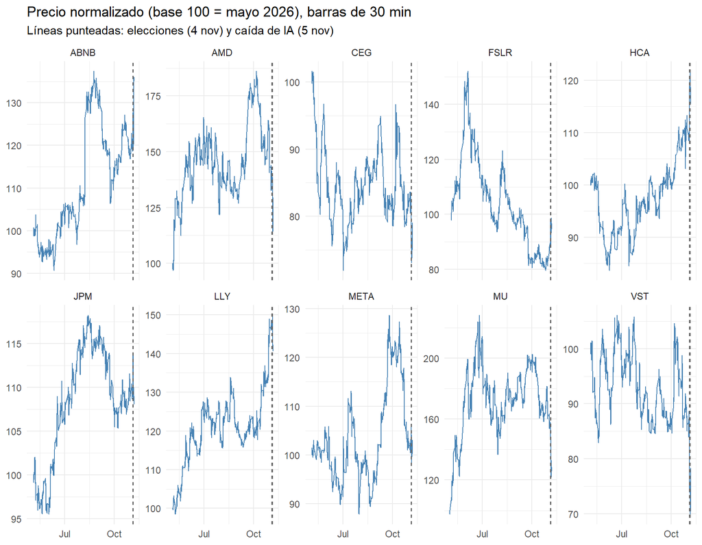

```r
p30 |>
  filter(ticker %in% ACCIONES) |>
  group_by(ticker) |>
  mutate(indice = 100 * close / dplyr::first(close)) |>
  ungroup() |>
  ggplot(aes(fh, indice)) +
  geom_line(linewidth = 0.4, colour = "steelblue") +
  geom_vline(xintercept = as.POSIXct(c("2026-11-04 09:30", "2026-11-05 09:30"), tz = TZ_MERCADO),
             linetype = "dashed", colour = "grey40") +
  facet_wrap(~ ticker, ncol = 5, scales = "free_y") +
  labs(title = "Precio normalizado (base 100 = mayo 2026), barras de 30 min",
       subtitle = "Líneas punteadas: elecciones (4 nov) y caída de IA (5 nov)", x = NULL, y = NULL) +
  theme_minimal()
```

## 4.1 Horas seleccionadas: estacionalidad intradía

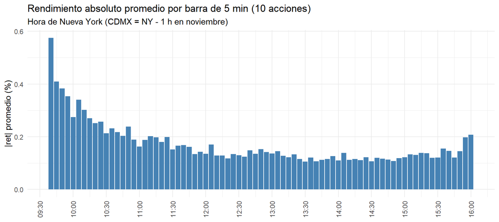

```r
acc_5m |>
  filter(!is.na(ret)) |>
  group_by(hora) |>
  summarise(vol_abs = mean(abs(ret)), volumen = mean(log_vol, na.rm = TRUE), .groups = "drop") |>
  ggplot(aes(as.POSIXct(paste("2026-01-01", hora)), vol_abs)) +
  geom_col(fill = "steelblue") +
  scale_x_datetime(date_labels = "%H:%M", date_breaks = "30 min") +
  labs(title = "Rendimiento absoluto promedio por barra de 5 min (10 acciones)",
       subtitle = "Hora de Nueva York (CDMX = NY - 1 h en noviembre)", x = NULL, y = "|ret| promedio (%)") +
  theme_minimal() + theme(axis.text.x = element_text(angle = 90, vjust = 0.5))
```

# 5 Regresión lineal simple: modelo de mercado (beta)

$$r_{i,t} = \alpha_i + \beta_i\, r_{SPY,t}
+ u_{i,t}$$

```r
mco_simple <- function(df) {
  m  <- lm(ret ~ r_spy, data = df)
  nw <- coeftest(m, vcov = NeweyWest(m, prewhite = FALSE))
  tibble(alfa = coef(m)[1], beta = coef(m)[2],
         ee_beta_NW = nw["r_spy", 2], t_beta = nw["r_spy", 3], p_beta = nw["r_spy", 4],
         R2 = summary(m)$r.squared, n = nobs(m))
}

betas <- imap_dfr(FRECS, function(df, frec)
  df |> filter(!is.na(ret), !is.na(r_spy)) |>
    group_by(ticker) |> group_modify(~ mco_simple(.x)) |> ungroup() |>
    mutate(frecuencia = frec, .before = 1))

knitr::kable(betas, digits = 3, caption = "Modelo de mercado por acción y frecuencia (EE Newey-West)")
```

Modelo de mercado por acción y frecuencia (EE Newey-West)

| frecuencia | ticker | alfa | beta | ee_beta_NW | t_beta | p_beta | R2 | n |
| --- | --- | --- | --- | --- | --- | --- | --- | --- |
| 5 min | MU | -0.006 | 3.052 | 0.142 | 21.451 | 0.000 | 0.429 | 1925 |
| 5 min | AMD | 0.002 | 3.262 | 0.256 | 12.750 | 0.000 | 0.421 | 1925 |
| 5 min | META | 0.000 | 1.382 | 0.101 | 13.692 | 0.000 | 0.194 | 1925 |
| 5 min | VST | 0.003 | 2.019 | 0.122 | 16.583 | 0.000 | 0.203 | 1925 |
| 5 min | CEG | 0.002 | 1.718 | 0.111 | 15.423 | 0.000 | 0.170 | 1925 |
| 5 min | FSLR | 0.007 | 1.991 | 0.125 | 15.921 | 0.000 | 0.200 | 1925 |
| 5 min | HCA | 0.000 | 0.139 | 0.081 | 1.710 | 0.087 | 0.001 | 1925 |
| 5 min | ABNB | 0.001 | 0.888 | 0.081 | 10.942 | 0.000 | 0.100 | 1925 |
| 5 min | LLY | -0.002 | 0.237 | 0.104 | 2.283 | 0.023 | 0.007 | 1925 |
| 5 min | JPM | 0.000 | 0.742 | 0.116 | 6.377 | 0.000 | 0.146 | 1925 |
| 30 min | MU | 0.012 | 3.275 | 0.197 | 16.631 | 0.000 | 0.309 | 1584 |
| 30 min | AMD | 0.019 | 3.000 | 0.125 | 23.914 | 0.000 | 0.381 | 1572 |
| 30 min | META | -0.001 | 1.297 | 0.088 | 14.795 | 0.000 | 0.203 | 1572 |
| 30 min | VST | -0.004 | 1.470 | 0.106 | 13.810 | 0.000 | 0.164 | 1572 |
| 30 min | CEG | -0.004 | 1.225 | 0.093 | 13.215 | 0.000 | 0.132 | 1572 |
| 30 min | FSLR | -0.016 | 1.686 | 0.121 | 13.883 | 0.000 | 0.144 | 1572 |
| 30 min | HCA | -0.027 | 0.083 | 0.072 | 1.153 | 0.249 | 0.001 | 1572 |
| 30 min | ABNB | -0.002 | 0.844 | 0.085 | 9.892 | 0.000 | 0.110 | 1572 |
| 30 min | LLY | -0.015 | 0.322 | 0.069 | 4.700 | 0.000 | 0.017 | 1572 |
| 30 min | JPM | 0.000 | 0.680 | 0.071 | 9.537 | 0.000 | 0.148 | 1572 |
| Diario | MU | 0.090 | 1.938 | 0.104 | 18.661 | 0.000 | 0.332 | 1206 |
| Diario | AMD | 0.015 | 2.191 | 0.087 | 25.278 | 0.000 | 0.425 | 1206 |
| Diario | META | -0.009 | 1.588 | 0.078 | 20.383 | 0.000 | 0.355 | 1206 |
| Diario | VST | 0.091 | 1.288 | 0.120 | 10.774 | 0.000 | 0.193 | 1206 |
| Diario | CEG | 0.100 | 1.196 | 0.097 | 12.288 | 0.000 | 0.181 | 1205 |
| Diario | FSLR | 0.032 | 1.090 | 0.111 | 9.833 | 0.000 | 0.120 | 1206 |
| Diario | HCA | 0.032 | 0.635 | 0.076 | 8.379 | 0.000 | 0.126 | 1206 |
| Diario | ABNB | -0.041 | 1.481 | 0.064 | 23.292 | 0.000 | 0.344 | 1206 |
| Diario | LLY | 0.119 | 0.549 | 0.050 | 10.898 | 0.000 | 0.084 | 1206 |
| Diario | JPM | 0.031 | 0.876 | 0.038 | 22.781 | 0.000 | 0.390 | 1206 |

```r
betas |>
  select(ticker, frecuencia, beta) |>
  pivot_wider(names_from = frecuencia, values_from = beta) |>
  knitr::kable(digits = 2, caption = "Beta por frecuencia")
```

Beta por frecuencia

| ticker | 5 min | 30 min | Diario |
| --- | --- | --- | --- |
| MU | 3.05 | 3.27 | 1.94 |
| AMD | 3.26 | 3.00 | 2.19 |
| META | 1.38 | 1.30 | 1.59 |
| VST | 2.02 | 1.47 | 1.29 |
| CEG | 1.72 | 1.23 | 1.20 |
| FSLR | 1.99 | 1.69 | 1.09 |
| HCA | 0.14 | 0.08 | 0.64 |
| ABNB | 0.89 | 0.84 | 1.48 |
| LLY | 0.24 | 0.32 | 0.55 |
| JPM | 0.74 | 0.68 | 0.88 |

```r
# 1) Una regresión por acción (diario)
modelos_simple <- acc_d |>
  filter(!is.na(ret), !is.na(r_spy)) |>
  droplevels() |>
  (\(d) split(d, d$ticker))() |>
  map(~ lm(ret ~ r_spy, data = .x))

# 2) Coeficientes con EE Newey-West e intervalos de confianza de cada acción
for (tk in ACCIONES) {
  m <- modelos_simple[[tk]]
  cat(sprintf("\n========== %s vs. SPY | R2 = %.3f | n = %d ==========\n",
              tk, summary(m)$r.squared, nobs(m)))
  print(coeftest(m, vcov = NeweyWest(m, prewhite = FALSE)))
  print(round(confint(m), 4))
}
```

```
##
## ========== MU vs. SPY | R2 = 0.332 | n = 1206 ==========
##
## t test of coefficients:
##
##             Estimate Std. Error t value Pr(>|t|)
## (Intercept) 0.089701   0.087820  1.0214   0.3073
## r_spy       1.937692   0.103836 18.6610   <2e-16 ***
## ---
## Signif. codes:  0 '***' 0.001 '**' 0.01 '*' 0.05 '.' 0.1 ' ' 1
##
##               2.5 % 97.5 %
## (Intercept) -0.0802 0.2596
## r_spy        1.7824 2.0930
##
## ========== AMD vs. SPY | R2 = 0.425 | n = 1206 ==========
##
## t test of coefficients:
##
##             Estimate Std. Error t value Pr(>|t|)
## (Intercept) 0.014941   0.081111  0.1842   0.8539
## r_spy       2.191433   0.086695 25.2776   <2e-16 ***
## ---
## Signif. codes:  0 '***' 0.001 '**' 0.01 '*' 0.05 '.' 0.1 ' ' 1
##
##               2.5 % 97.5 %
## (Intercept) -0.1426 0.1725
## r_spy        2.0474 2.3355
##
## ========== META vs. SPY | R2 = 0.355 | n = 1206 ==========
##
## t test of coefficients:
##
##               Estimate Std. Error t value Pr(>|t|)
## (Intercept) -0.0087932  0.0714037 -0.1231    0.902
## r_spy        1.5884842  0.0779301 20.3834   <2e-16 ***
## ---
## Signif. codes:  0 '***' 0.001 '**' 0.01 '*' 0.05 '.' 0.1 ' ' 1
##
##               2.5 % 97.5 %
```

[output cut: 85 more lines]

```
## r_spy       0.4466 0.6512
##
## ========== JPM vs. SPY | R2 = 0.390 | n = 1206 ==========
##
## t test of coefficients:
##
##             Estimate Std. Error t value Pr(>|t|)
## (Intercept) 0.031161   0.033414  0.9326   0.3512
## r_spy       0.876313   0.038467 22.7806   <2e-16 ***
## ---
## Signif. codes:  0 '***' 0.001 '**' 0.01 '*' 0.05 '.' 0.1 ' ' 1
##
##               2.5 % 97.5 %
## (Intercept) -0.0367 0.0990
## r_spy        0.8143 0.9383
```

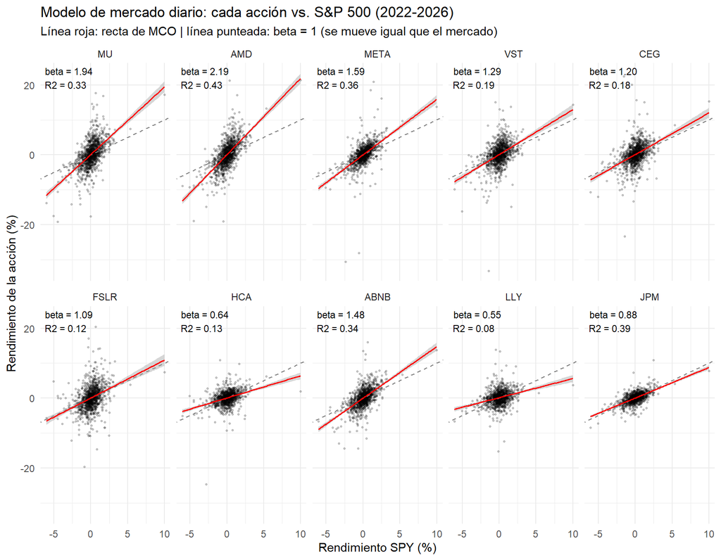

```r
# 3) Gráfica: las 10 acciones contra el SPY, con su beta y R2
etiquetas <- betas |>
  filter(frecuencia == "Diario") |>
  mutate(texto = sprintf("beta = %.2f\nR2 = %.2f", beta, R2))

ggplot(filter(acc_d, !is.na(ret), !is.na(r_spy)), aes(r_spy, ret)) +
  geom_point(alpha = 0.2, size = 0.5) +
  geom_abline(slope = 1, intercept = 0, linetype = "dashed", colour = "grey50") +
  geom_smooth(method = "lm", se = TRUE, colour = "red", linewidth = 0.6) +
  geom_text(data = etiquetas, aes(x = -Inf, y = Inf, label = texto),
            hjust = -0.1, vjust = 1.2, size = 3, inherit.aes = FALSE) +
  facet_wrap(~ ticker, ncol = 5) +
  labs(title = "Modelo de mercado diario: cada acción vs. S&P 500 (2022-2026)",
       subtitle = "Línea roja: recta de MCO | línea punteada: beta = 1 (se mueve igual que el mercado)",
       x = "Rendimiento SPY (%)", y = "Rendimiento de la acción (%)") +
  theme_minimal()
```

# 6 Regresión lineal múltiple

$$r_{i,t} = \beta_0 + \beta_1 r_{SPY,t} +
\beta_2 f_{tec,t} + \beta_3 \Delta VIX_t +
\beta_4\,\text{eventos/estacionalidad} + u_t$$

- **Intradía:** + `apertura` + `cierre` + `d_eleccion` + `d_selloff`
- **Diario:** + `lunes` + `d_eleccion` + `d_selloff`

```r
formula_mult <- function(frec) {
  if (frec == "Diario") ret ~ r_spy + f_tec + d_vix + lunes + d_eleccion + d_selloff
  else                  ret ~ r_spy + f_tec + d_vix + apertura + cierre + d_eleccion + d_selloff
}

mco_mult <- function(df, frec) {
  m  <- lm(formula_mult(frec), data = df)
  nw <- coeftest(m, vcov = NeweyWest(m, prewhite = FALSE))
  est <- setNames(nw[, 1], rownames(nw))
  tv  <- setNames(nw[, 3], paste0("t_", rownames(nw)))
  tibble(!!!as.list(round(est, 4)), !!!as.list(round(tv, 2)),
         R2_aj   = summary(m)$adj.r.squared,
         VIF_max = max(vif(m)),
         BP_p    = bptest(m)$p.value,
         DW      = unname(dwtest(m)$statistic),
         n       = nobs(m))
}

mult <- imap_dfr(FRECS, function(df, frec)
  df |> filter(!is.na(ret), !is.na(r_spy), !is.na(d_vix)) |>
    group_by(ticker) |> group_modify(~ mco_mult(.x, frec)) |> ungroup() |>
    mutate(frecuencia = frec, .before = 1))

mult |>
  select(frecuencia, ticker, r_spy, t_r_spy, f_tec, t_f_tec, d_vix, t_d_vix,
         d_selloff, t_d_selloff, R2_aj, VIF_max, BP_p, DW) |>
  knitr::kable(digits = 3, caption = "Regresión múltiple: coeficientes y t de Newey-West")
```

Regresión múltiple: coeficientes y t de Newey-West

| frecuencia | ticker | r_spy | t_r_spy | f_tec | t_f_tec | d_vix | t_d_vix | d_selloff | t_d_selloff | R2_aj | VIF_max | BP_p | DW |
| --- | --- | --- | --- | --- | --- | --- | --- | --- | --- | --- | --- | --- | --- |
| 5 min | MU | 0.884 | 4.51 | 3.818 | 16.67 | -0.155 | -2.46 | -0.072 | -1.80 | 0.649 | 3.779 | 0.000 | 1.954 |
| 5 min | AMD | 1.170 | 6.92 | 4.255 | 15.97 | -0.046 | -0.83 | -0.022 | -1.28 | 0.657 | 3.779 | 0.000 | 2.139 |
| 5 min | META | 1.067 | 7.87 | 0.492 | 2.71 | -0.039 | -1.20 | 0.018 | 0.42 | 0.201 | 3.779 | 0.000 | 2.187 |
| 5 min | VST | 1.703 | 6.84 | 0.668 | 2.76 | -0.009 | -0.18 | 0.030 | 1.50 | 0.210 | 3.779 | 0.000 | 2.016 |
| 5 min | CEG | 1.570 | 7.62 | 0.464 | 2.19 | 0.016 | 0.36 | 0.070 | 2.00 | 0.174 | 3.779 | 0.000 | 2.028 |
| 5 min | FSLR | 1.855 | 8.14 | 0.402 | 1.32 | 0.009 | 0.19 | 0.055 | 1.16 | 0.209 | 3.779 | 0.000 | 2.109 |
| 5 min | HCA | 0.768 | 5.30 | -1.115 | -6.25 | 0.047 | 1.28 | 0.006 | 0.28 | 0.029 | 3.779 | 0.049 | 2.345 |
| 5 min | ABNB | 1.254 | 9.65 | -0.755 | -3.87 | 0.004 | 0.11 | 0.017 | 0.70 | 0.123 | 3.779 | 0.000 | 2.155 |
| 5 min | LLY | 0.902 | 6.25 | -1.503 | -8.00 | -0.011 | -0.35 | -0.015 | -0.50 | 0.101 | 3.779 | 0.000 | 2.079 |
| 5 min | JPM | 1.094 | 11.01 | -1.275 | -11.17 | -0.096 | -3.37 | -0.018 | -0.85 | 0.303 | 3.779 | 0.000 | 2.210 |
| 30 min | MU | 0.440 | 2.20 | 5.888 | 27.89 | -0.113 | -1.20 | -0.433 | -2.61 | 0.654 | 3.041 | 0.000 | 2.151 |
| 30 min | AMD | 0.789 | 5.52 | 4.463 | 25.87 | -0.132 | -2.31 | -0.214 | -2.67 | 0.672 | 3.041 | 0.000 | 2.060 |
| 30 min | META | 1.297 | 8.12 | -0.339 | -2.20 | -0.113 | -1.29 | 0.339 | 3.12 | 0.210 | 3.041 | 0.004 | 2.040 |
| 30 min | VST | 0.979 | 6.13 | 0.595 | 3.36 | -0.152 | -2.74 | 0.160 | 1.56 | 0.177 | 3.041 | 0.000 | 1.998 |
| 30 min | CEG | 0.935 | 5.65 | 0.316 | 1.72 | -0.115 | -1.94 | 0.430 | 4.36 | 0.143 | 3.041 | 0.000 | 2.025 |
| 30 min | FSLR | 0.686 | 3.78 | 1.361 | 5.57 | -0.278 | -3.53 | 0.492 | 3.12 | 0.192 | 3.041 | 0.000 | 2.025 |
| 30 min | HCA | 0.693 | 5.93 | -1.384 | -11.73 | -0.006 | -0.12 | -0.024 | -0.21 | 0.103 | 3.041 | 0.000 | 2.000 |
| 30 min | ABNB | 1.301 | 10.49 | -1.081 | -9.74 | -0.029 | -0.47 | 0.270 | 1.66 | 0.171 | 3.041 | 0.000 | 1.996 |
| 30 min | LLY | 0.806 | 6.22 | -1.160 | -9.03 | -0.011 | -0.19 | -0.254 | -4.20 | 0.093 | 3.041 | 0.000 | 2.095 |
| 30 min | JPM | 1.120 | 12.76 | -1.202 | -16.79 | -0.063 | -1.06 | -0.021 | -0.28 | 0.310 | 3.041 | 0.000 | 2.067 |
| Diario | MU | 0.956 | 6.18 | 2.803 | 8.41 | -0.157 | -1.42 | -7.004 | -6.90 | 0.467 | 3.205 | 0.728 | 2.012 |
| Diario | AMD | 1.314 | 9.31 | 3.034 | 15.25 | -0.019 | -0.17 | -6.149 | -7.16 | 0.574 | 3.205 | 0.931 | 2.013 |
| Diario | META | 1.373 | 11.13 | 1.486 | 5.22 | 0.142 | 2.09 | 3.780 | 6.74 | 0.413 | 3.205 | 0.338 | 1.969 |
| Diario | VST | 0.828 | 6.51 | 0.380 | 1.52 | -0.304 | -4.09 | 1.556 | 1.95 | 0.229 | 3.205 | 0.027 | 2.078 |
| Diario | CEG | 0.981 | 8.84 | 0.304 | 1.35 | -0.124 | -1.96 | 3.869 | 5.45 | 0.190 | 3.205 | 0.349 | 1.996 |
| Diario | FSLR | 0.749 | 4.65 | 0.765 | 3.40 | -0.118 | -1.47 | 7.036 | 10.53 | 0.130 | 3.205 | 0.650 | 1.963 |
| Diario | HCA | 1.078 | 11.81 | -1.111 | -7.78 | 0.113 | 1.88 | 0.434 | 0.74 | 0.210 | 3.205 | 0.309 | 2.143 |
| Diario | ABNB | 1.376 | 11.19 | 0.522 | 2.76 | 0.023 | 0.37 | 3.503 | 6.75 | 0.351 | 3.205 | 0.196 | 2.013 |
| Diario | LLY | 0.635 | 8.45 | -0.900 | -6.02 | -0.124 | -2.60 | -1.636 | -3.95 | 0.127 | 3.205 | 0.407 | 1.949 |
| Diario | JPM | 1.058 | 21.13 | -1.064 | -13.32 | -0.084 | -2.32 | -0.920 | -2.75 | 0.499 | 3.205 | 0.838 | 2.081 |

## 6.1 Ejemplo detallado y diagnóstico: diario

```r
# Una regresión múltiple por acción (diario)
modelos_mult <- acc_d |>
  filter(!is.na(ret), !is.na(r_spy), !is.na(d_vix)) |>
  droplevels() |>
  (\(d) split(d, d$ticker))() |>
  map(~ lm(formula_mult("Diario"), data = .x))
modelos_mult <- modelos_mult[ACCIONES]

# Coeficientes con errores estándar Newey-West de cada acción
for (tk in ACCIONES) {
  m <- modelos_mult[[tk]]
  cat(sprintf("\n========== %s | R2 ajustado = %.3f | n = %d ==========\n",
              tk, summary(m)$adj.r.squared, nobs(m)))
  print(coeftest(m, vcov = NeweyWest(m, prewhite = FALSE)))
}
```

```
##
## ========== MU | R2 ajustado = 0.467 | n = 1206 ==========
##
## t test of coefficients:
##
##             Estimate Std. Error  t value  Pr(>|t|)
## (Intercept)  0.10664    0.09230   1.1554    0.2482
## r_spy        0.95616    0.15467   6.1818 8.670e-10 ***
## f_tec        2.80245    0.33333   8.4075 < 2.2e-16 ***
## d_vix       -0.15680    0.11023  -1.4224    0.1552
## lunes        0.06635    0.19831   0.3346    0.7380
## d_eleccion  -7.71683    0.46310 -16.6635 < 2.2e-16 ***
## d_selloff   -7.00399    1.01552  -6.8970 8.577e-12 ***
## ---
## Signif. codes:  0 '***' 0.001 '**' 0.01 '*' 0.05 '.' 0.1 ' ' 1
##
##
## ========== AMD | R2 ajustado = 0.574 | n = 1206 ==========
##
## t test of coefficients:
##
##              Estimate Std. Error t value  Pr(>|t|)
## (Intercept)  0.015557   0.080576  0.1931   0.84693
## r_spy        1.314065   0.141080  9.3144 < 2.2e-16 ***
## f_tec        3.034433   0.198999 15.2485 < 2.2e-16 ***
## d_vix       -0.018799   0.110725 -0.1698   0.86521
## lunes        0.078670   0.185414  0.4243   0.67143
## d_eleccion   0.787735   0.364272  2.1625   0.03078 *
## d_selloff   -6.148517   0.858871 -7.1588 1.415e-12 ***
## ---
## Signif. codes:  0 '***' 0.001 '**' 0.01 '*' 0.05 '.' 0.1 ' ' 1
##
##
## ========== META | R2 ajustado = 0.413 | n = 1206 ==========
##
## t test of coefficients:
##
##               Estimate Std. Error t value  Pr(>|t|)
## (Intercept)  0.0023398  0.0756357  0.0309   0.97533
## r_spy        1.3728831  0.1232953 11.1349 < 2.2e-16 ***
```

[output cut: 104 more lines]

```
##
## ========== JPM | R2 ajustado = 0.499 | n = 1206 ==========
##
## t test of coefficients:
##
##                Estimate  Std. Error  t value  Pr(>|t|)
## (Intercept)  0.03231342  0.03475943   0.9296  0.352750
## r_spy        1.05793871  0.05005625  21.1350 < 2.2e-16 ***
## f_tec       -1.06409840  0.07986060 -13.3244 < 2.2e-16 ***
## d_vix       -0.08366336  0.03612765  -2.3158  0.020739 *
## lunes       -0.00012984  0.07683701  -0.0017  0.998652
## d_eleccion   1.26457432  0.16597361   7.6191 5.165e-14 ***
## d_selloff   -0.91963211  0.33409388  -2.7526  0.006001 **
## ---
## Signif. codes:  0 '***' 0.001 '**' 0.01 '*' 0.05 '.' 0.1 ' ' 1
```

```r
# Tabla de pruebas y diagnóstico para las 10 acciones
pruebas_mult <- imap_dfr(modelos_mult, function(m, tk) {
  d  <- model.frame(m)
  m0 <- lm(ret ~ r_spy, data = d)                 # modelo simple con la misma muestra
  nw <- NeweyWest(m, prewhite = FALSE)
  dw <- dwtest(m)
  tibble(ticker = tk,
         R2aj_simple   = summary(m0)$adj.r.squared,
         R2aj_multiple = summary(m)$adj.r.squared,
         F_anidado_p   = anova(m0, m)$`Pr(>F)`[2],
         F_ftec_vix_p  = linearHypothesis(m, c("f_tec = 0", "d_vix = 0"), vcov. = nw)$`Pr(>F)`[2],
         VIF_max       = max(vif(m)),
         BP_p          = bptest(m)$p.value,
         DW            = unname(dw$statistic),
         DW_p          = dw$p.value)
})

knitr::kable(pruebas_mult, digits = 3,
             caption = "Pruebas de la regresión múltiple diaria por acción")
```

Pruebas de la regresión múltiple diaria por acción

| ticker | R2aj_simple | R2aj_multiple | F_anidado_p | F_ftec_vix_p | VIF_max | BP_p | DW | DW_p |
| --- | --- | --- | --- | --- | --- | --- | --- | --- |
| MU | 0.332 | 0.467 | 0.000 | 0.000 | 3.205 | 0.728 | 2.012 | 0.586 |
| AMD | 0.425 | 0.574 | 0.000 | 0.000 | 3.205 | 0.931 | 2.013 | 0.596 |
| META | 0.355 | 0.413 | 0.000 | 0.000 | 3.205 | 0.338 | 1.969 | 0.297 |
| VST | 0.193 | 0.229 | 0.000 | 0.000 | 3.205 | 0.027 | 2.078 | 0.914 |
| CEG | 0.181 | 0.190 | 0.002 | 0.070 | 3.205 | 0.349 | 1.996 | 0.474 |
| FSLR | 0.120 | 0.130 | 0.002 | 0.001 | 3.205 | 0.650 | 1.963 | 0.266 |
| HCA | 0.125 | 0.210 | 0.000 | 0.000 | 3.205 | 0.309 | 2.143 | 0.994 |
| ABNB | 0.344 | 0.351 | 0.002 | 0.011 | 3.205 | 0.196 | 2.013 | 0.594 |
| LLY | 0.084 | 0.127 | 0.000 | 0.000 | 3.205 | 0.407 | 1.949 | 0.193 |
| JPM | 0.389 | 0.499 | 0.000 | 0.000 | 3.205 | 0.838 | 2.081 | 0.922 |

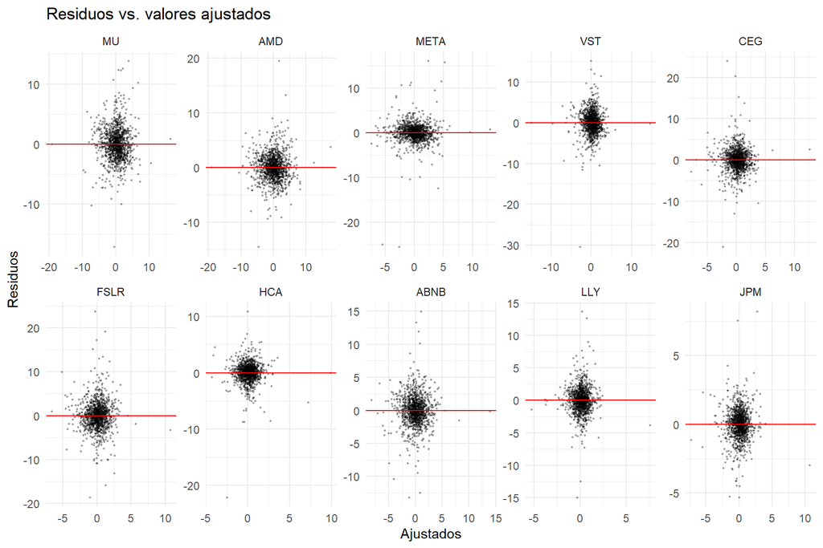

```r
resid_df <- imap_dfr(modelos_mult, ~ tibble(ticker = .y, ajustado = fitted(.x),
                                            residuo = resid(.x))) |>
  mutate(ticker = factor(ticker, levels = ACCIONES))

ggplot(resid_df, aes(ajustado, residuo)) +
  geom_point(size = 0.4, alpha = 0.3) +
  geom_hline(yintercept = 0, colour = "red") +
  facet_wrap(~ ticker, ncol = 5, scales = "free") +
  labs(title = "Residuos vs. valores ajustados", x = "Ajustados", y = "Residuos") +
  theme_minimal()
```

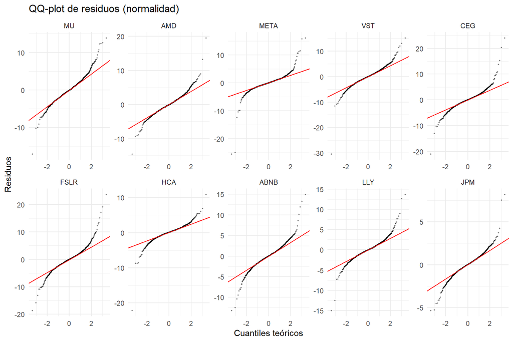

```r
ggplot(resid_df, aes(sample = residuo)) +
  stat_qq(size = 0.4, alpha = 0.4) +
  stat_qq_line(colour = "red") +
  facet_wrap(~ ticker, ncol = 5, scales = "free") +
  labs(title = "QQ-plot de residuos (normalidad)", x = "Cuantiles teóricos", y = "Residuos") +
  theme_minimal()
```

# 7 Datos de panel: reportes trimestrales

**Pregunta:** ¿qué fundamentales del reporte trimestral explican el rendimiento de la acción?

$$r_{i,t} = \beta_1\,\Delta EPS/P_{i,t} +
\beta_2\,\text{crec. ingresos}_{i,t} + \beta_3\,\text{margen neto}_{i,t}
+ \beta_4\,\text{deuda/activos}_{i,t} + \beta_5 \ln(\text{cap.
mercado})_{i,t-1} + \alpha_i + u_{i,t}$$

```r
fin_trim_cercano <- function(f) {
  sig <- ceiling_date(f, "quarter") - days(1)
  ant <- floor_date(f, "quarter") - days(1)
  if_else(as.numeric(sig - f) <= as.numeric(f - ant), sig, ant)
}

# Precio de cierre al final de cada trimestre (último día hábil <= fin de trimestre)
precio_al <- function(tk, fechas) {
  s <- pd_ |> filter(ticker == tk) |> arrange(fecha)
  i <- findInterval(fechas, s$fecha)
  ifelse(i == 0, NA_real_, s$close[pmax(i, 1)])     # NA si la fecha es anterior al primer precio
}

panel <- trim_crudo |>
  filter(ticker %in% ACCIONES) |>
  mutate(trimestre = fin_trim_cercano(fin_periodo)) |>
  arrange(ticker, trimestre) |>
  group_by(ticker) |>
  mutate(precio     = precio_al(dplyr::first(ticker), trimestre),
         precio_ant = precio_al(dplyr::first(ticker), floor_date(trimestre, "quarter") - days(1)),
         precio_sig = precio_al(dplyr::first(ticker), ceiling_date(trimestre + days(1), "quarter") - days(1)),
         ret_trim   = 100 * log(precio / precio_ant),
         ret_sig    = 100 * log(precio_sig / precio),
         cap_merc   = acciones_c * precio,                       # millones de USD
         ln_cap     = log(dplyr::lag(cap_merc)),
         d_eps_p    = 100 * (eps - dplyr::lag(eps, 4)) / precio,
         crec_ing   = 100 * log(ingresos / dplyr::lag(ingresos, 4))) |>
  ungroup() |>
  mutate(ret_sig = if_else(trimestre >= floor_date(max(pd_$fecha), "quarter") - days(1),
                           NA_real_, ret_sig),                 # el trimestre siguiente aún no termina
         etiqueta = paste0(year(trimestre), "T", quarter(trimestre)))

# Verificación: un solo reporte por empresa y trimestre
stopifnot(!any(duplicated(panel[, c("ticker", "trimestre")])))

vars_panel <- c("d_eps_p", "crec_ing", "margen", "deuda_act", "ln_cap")
panel_m <- panel |> filter(if_all(all_of(c("ret_trim", vars_panel)), ~ !is.na(.x)))

panel_m |> count(ticker, name = "trimestres_utiles")
```

| ticker | trimestres_utiles |
| --- | --- |
| ABNB | 16 |
| AMD | 16 |
| CEG | 15 |
| FSLR | 16 |
| HCA | 16 |
| JPM | 16 |
| LLY | 16 |
| META | 16 |
| MU | 13 |
| VST | 15 |

```r
summary(select(panel_m, ret_trim, ret_sig, all_of(vars_panel)))
```

```
##     ret_trim          ret_sig           d_eps_p            crec_ing
##  Min.   :-34.737   Min.   :-34.737   Min.   :-9.43966   Min.   :-50.477
##  1st Qu.: -4.441   1st Qu.: -5.460   1st Qu.:-0.03651   1st Qu.:  6.817
##  Median :  8.181   Median :  8.012   Median : 0.19191   Median : 14.904
##  Mean   :  8.943   Mean   :  8.895   Mean   : 0.43529   Mean   : 17.979
##  3rd Qu.: 18.558   3rd Qu.: 18.558   3rd Qu.: 0.60413   3rd Qu.: 25.718
##  Max.   :122.867   Max.   :122.867   Max.   :16.91429   Max.   :156.709
##                    NAs    :8
##      margen         deuda_act         ln_cap
##  Min.   :-35.66   Min.   : 0.56   Min.   : 9.049
##  1st Qu.:  9.62   1st Qu.: 7.98   1st Qu.:11.049
##  Median : 19.32   Median :16.65   Median :11.534
##  Mean   : 20.45   Mean   :24.01   Mean   :11.845
##  3rd Qu.: 32.30   3rd Qu.:38.19   3rd Qu.:13.054
##  Max.   :128.76   Max.   :79.58   Max.   :14.434
##
```

```r
pdat <- pdata.frame(as.data.frame(panel_m), index = c("ticker", "etiqueta"))
f_cont <- ret_trim ~ d_eps_p + crec_ing + margen + deuda_act + ln_cap

mod_pool <- plm(f_cont, data = pdat, model = "pooling")
mod_fe   <- plm(f_cont, data = pdat, model = "within", effect = "individual")
mod_fe2  <- plm(f_cont, data = pdat, model = "within", effect = "twoways")
mod_re   <- tryCatch(plm(f_cont, data = pdat, model = "random"),
                     error = function(e) plm(f_cont, data = pdat, model = "random",
                                             random.method = "amemiya"))

# Errores estándar robustos agrupados por empresa (Arellano)
rob <- function(m) coeftest(m, vcov = vcovHC(m, method = "arellano", type = "HC1", cluster = "group"))

tabla_panel <- function(modelos) {
  map_dfr(names(modelos), function(nm) {
    ct <- rob(modelos[[nm]])
    tibble(modelo = nm, variable = rownames(ct), coef = ct[, 1], t = ct[, 3], p = ct[, 4])
  }) |>
    mutate(celda = sprintf("%.3f%s", coef, ifelse(p < 0.01, "***", ifelse(p < 0.05, "**", ifelse(p < 0.1, "*", ""))))) |>
    select(modelo, variable, celda) |>
    pivot_wider(names_from = modelo, values_from = celda, values_fill = "")
}

modelos <- list("MCO agrupado" = mod_pool, "Efectos fijos" = mod_fe,
                "EF dos vías" = mod_fe2, "Efectos aleatorios" = mod_re)
knitr::kable(tabla_panel(modelos),
             caption = "Panel: rendimiento trimestral contemporáneo (EE robustos por empresa; *** 1%, ** 5%, * 10%)")
```

Panel: rendimiento trimestral contemporáneo (EE robustos por empresa; *** 1%, ** 5%, * 10%)

| variable | MCO agrupado | Efectos fijos | EF dos vías | Efectos aleatorios |
| --- | --- | --- | --- | --- |
| (Intercept) | 19.415 |  |  | 19.415 |
| d_eps_p | -0.167 | -1.352* | -1.441** | -0.167 |
| crec_ing | 0.147* | 0.200 | 0.237** | 0.147* |
| margen | 0.021 | 0.267 | 0.219** | 0.021 |
| deuda_act | -0.022 | -0.568 | -0.889 | -0.022 |
| ln_cap | -1.093 | -16.376*** | -20.386*** | -1.093 |

```r
sapply(modelos, function(m) round(summary(m)$r.squared[["rsq"]], 3))
```

```
##       MCO agrupado      Efectos fijos        EF dos vías Efectos aleatorios
##              0.027              0.131              0.162              0.027
```

## 7.1 Pruebas para elegir el modelo

```r
cat("1) Prueba F de efectos individuales (H0: MCO agrupado es suficiente)\n")
```

```
## 1) Prueba F de efectos individuales (H0: MCO agrupado es suficiente)
```

```r
pFtest(mod_fe, mod_pool)
```

```
##
##  F test for individual effects
##
## data:  f_cont
## F = 3.0073, df1 = 9, df2 = 140, p-value = 0.002607
## alternative hypothesis: significant effects
```

```r
cat("\n2) Breusch-Pagan LM (H0: varianza del efecto aleatorio = 0, MCO agrupado es suficiente)\n")
```

```
##
## 2) Breusch-Pagan LM (H0: varianza del efecto aleatorio = 0, MCO agrupado es suficiente)
```

```r
plmtest(mod_pool, type = "bp")
```

```
##
##  Lagrange Multiplier Test - (Breusch-Pagan)
##
## data:  f_cont
## chisq = 0.14524, df = 1, p-value = 0.7031
## alternative hypothesis: significant effects
```

```r
cat("\n3) Hausman (H0: efectos aleatorios es consistente y eficiente)\n")
```

```
##
## 3) Hausman (H0: efectos aleatorios es consistente y eficiente)
```

```r
phtest(mod_fe, mod_re)
```

```
##
##  Hausman Test
##
## data:  f_cont
## chisq = 26.542, df = 5, p-value = 7.004e-05
## alternative hypothesis: one model is inconsistent
```

```r
cat("\n4) Efectos de tiempo (H0: no hacen falta dummies de trimestre)\n")
```

```
##
## 4) Efectos de tiempo (H0: no hacen falta dummies de trimestre)
```

```r
pFtest(mod_fe2, mod_fe)
```

```
##
##  F test for twoways effects
##
## data:  f_cont
## F = 3.9758, df1 = 15, df2 = 125, p-value = 7.695e-06
## alternative hypothesis: significant effects
```

**Cómo decidir (Gujarati cap. 16):**

1. **Prueba F** con p < 0.05: hay diferencias permanentes entre empresas → MCO agrupado está sesgado.
2. **Breusch-Pagan LM** con p < 0.05: el efecto aleatorio es relevante → preferir RE sobre agrupado.
3. **Hausman** con p < 0.05: los efectos individuales están correlacionados con los regresores → **efectos fijos**. Con p > 0.05 → **efectos aleatorios** (más eficiente).
4. Si los efectos de tiempo son significativos, el trimestre común (por ejemplo, el mercado en general) importa → modelo de **dos vías**. En acciones casi siempre pasa, porque todas se mueven con el mercado.

# 8 Series de tiempo: estacionariedad y pronóstico ARIMA

## 8.1 Prueba de raíz unitaria (Dickey-Fuller aumentada)

```r
adf_p <- function(x) suppressWarnings(adf.test(na.omit(as.numeric(x)))$p.value)

pd_precios <- pd_ |> filter(ticker %in% ACCIONES, fecha >= INICIO_D)
adf_tab <- pd_precios |>
  group_by(ticker) |>
  summarise(p_log_precio  = adf_p(log(close)),
            p_rendimiento = adf_p(ret), .groups = "drop") |>
  mutate(precio = if_else(p_log_precio < 0.05, "Estacionaria", "Raíz unitaria"),
         rend   = if_else(p_rendimiento < 0.05, "Estacionaria", "Raíz unitaria"))
knitr::kable(adf_tab, digits = 4, caption = "ADF diario (H0: raíz unitaria). p = 0.01 significa p <= 0.01")
```

ADF diario (H0: raíz unitaria). p = 0.01 significa p <= 0.01

| ticker | p_log_precio | p_rendimiento | precio | rend |
| --- | --- | --- | --- | --- |
| ABNB | 0.0677 | 0.01 | Raíz unitaria | Estacionaria |
| AMD | 0.4111 | 0.01 | Raíz unitaria | Estacionaria |
| CEG | 0.7121 | 0.01 | Raíz unitaria | Estacionaria |
| FSLR | 0.5412 | 0.01 | Raíz unitaria | Estacionaria |
| HCA | 0.1780 | 0.01 | Raíz unitaria | Estacionaria |
| JPM | 0.0109 | 0.01 | Estacionaria | Estacionaria |
| LLY | 0.4547 | 0.01 | Raíz unitaria | Estacionaria |
| META | 0.3892 | 0.01 | Raíz unitaria | Estacionaria |
| MU | 0.6844 | 0.01 | Raíz unitaria | Estacionaria |
| VST | 0.9507 | 0.01 | Raíz unitaria | Estacionaria |

## 8.2 Selección Box-Jenkins, validación y pronóstico

Para cada acción y frecuencia:

1. Se reserva la **última sesión** (78 barras de 5 min o 13 de 30 min) o los **últimos 20 días** (diario) para validar fuera de muestra.
2. Se elige el ARIMA(p,1,q) con menor **AIC** (`auto.arima`). Con BIC, más estricto, casi todas las series quedan como ARIMA(0,1,0), es decir, una caminata aleatoria; puedes comprobarlo cambiando `CRITERIO`.
3. Se compara su RMSE contra el **modelo ingenuo** (caminata aleatoria: último precio).
4. Se reestima con toda la muestra y se **pronostica la siguiente sesión** (lunes 9 de noviembre).

```r
HOLD <- c("5 min" = 78, "30 min" = 13, "Diario" = 20)   # validación fuera de muestra
HFC  <- c("5 min" = 78, "30 min" = 13, "Diario" = 5)    # pronóstico hacia adelante
CRITERIO <- "aic"   # "bic" es más estricto y casi siempre elige la caminata aleatoria ARIMA(0,1,0)

serie_log <- function(frec, tk) {
  src <- switch(frec, "5 min" = p5, "30 min" = p30, "Diario" = filter(pd_, fecha >= INICIO_D))
  s <- src |> filter(ticker == tk) |> arrange(fh)
  list(y = log(s$close), fh = s$fh)
}

# La deriva (tendencia) solo se permite en diario: en intradía una deriva estimada con
# un mes de datos se acumularía 78 veces en una sesión y daría pronósticos irreales.
ajustar_arima <- function(y, deriva = TRUE) {
  auto.arima(y, d = 1, max.p = 3, max.q = 3, ic = CRITERIO,
             stepwise = TRUE, approximation = FALSE, allowdrift = deriva)
}

etiqueta_arima <- function(m) {
  o <- arimaorder(m)
  paste0(sprintf("ARIMA(%d,1,%d)", o[1], o[3]), if ("drift" %in% names(coef(m))) " c/deriva" else "")
}

arima_eval <- function(frec, tk) {
  s <- serie_log(frec, tk); y <- s$y
  H <- HOLD[[frec]]
  y_tr <- head(y, -H); y_te <- tail(y, H)

  m_tr <- ajustar_arima(y_tr, deriva = frec == "Diario")
  fc   <- forecast(m_tr, h = H, level = 95)
  real <- exp(y_te); med <- exp(as.numeric(fc$mean))
  li   <- exp(as.numeric(fc$lower)); ls <- exp(as.numeric(fc$upper))
  ing  <- rep(exp(tail(y_tr, 1)), H)

  m_full <- ajustar_arima(y, deriva = frec == "Diario")
  fc_f   <- forecast(m_full, h = HFC[[frec]], level = 95)
  p0     <- exp(tail(y, 1))
  pf     <- exp(as.numeric(fc_f$mean))

  ord <- arimaorder(m_full)
  lb  <- Box.test(residuals(m_full), lag = 10, type = "Ljung-Box", fitdf = ord[1] + ord[3])$p.value

  tibble(frecuencia = frec, ticker = tk,
         modelo_validacion = etiqueta_arima(m_tr),
         modelo_pronostico = etiqueta_arima(m_full),
         LjungBox_p = lb,
         RMSE_ARIMA = sqrt(mean((med - real)^2)),
         RMSE_ingenuo = sqrt(mean((ing - real)^2)),
         ganador = case_when(abs(RMSE_ARIMA - RMSE_ingenuo) < 1e-8 ~ "Empate (caminata aleatoria)",
                             RMSE_ARIMA < RMSE_ingenuo ~ "ARIMA", TRUE ~ "Ingenuo"),
         cobertura_IC95 = mean(real >= li & real <= ls),
         precio_actual = p0,
         pronostico_fin = tail(pf, 1),
         IC95_inf = exp(tail(as.numeric(fc_f$lower), 1)),
         IC95_sup = exp(tail(as.numeric(fc_f$upper), 1)),
         rend_esperado = 100 * log(tail(pf, 1) / p0))
}
```

```r
arima_res <- expand_grid(frecuencia = names(FRECS), ticker = ACCIONES) |>
  pmap_dfr(function(frecuencia, ticker) arima_eval(frecuencia, ticker))

arima_res |>
  select(frecuencia, ticker, modelo_validacion, RMSE_ARIMA, RMSE_ingenuo, ganador, cobertura_IC95) |>
  knitr::kable(digits = 3, caption = "Validación fuera de muestra (última sesión / últimos 20 días)")
```

Validación fuera de muestra (última sesión / últimos 20 días)

| frecuencia | ticker | modelo_validacion | RMSE_ARIMA | RMSE_ingenuo | ganador | cobertura_IC95 |
| --- | --- | --- | --- | --- | --- | --- |
| 5 min | MU | ARIMA(0,1,0) | 35.043 | 35.043 | Empate (caminata aleatoria) | 0.692 |
| 5 min | AMD | ARIMA(1,1,0) | 41.281 | 42.046 | ARIMA | 0.000 |
| 5 min | META | ARIMA(0,1,2) | 12.627 | 12.716 | ARIMA | 0.782 |
| 5 min | VST | ARIMA(0,1,0) | 10.734 | 10.734 | Empate (caminata aleatoria) | 0.000 |
| 5 min | CEG | ARIMA(2,1,2) | 10.887 | 10.912 | ARIMA | 0.744 |
| 5 min | FSLR | ARIMA(3,1,0) | 6.042 | 6.147 | ARIMA | 0.808 |
| 5 min | HCA | ARIMA(2,1,3) | 11.835 | 11.863 | ARIMA | 0.756 |
| 5 min | ABNB | ARIMA(0,1,0) | 20.311 | 20.311 | Empate (caminata aleatoria) | 0.000 |
| 5 min | LLY | ARIMA(0,1,0) | 4.053 | 4.053 | Empate (caminata aleatoria) | 1.000 |
| 5 min | JPM | ARIMA(2,1,2) | 1.452 | 1.447 | Ingenuo | 0.987 |
| 30 min | MU | ARIMA(0,1,0) | 35.879 | 35.879 | Empate (caminata aleatoria) | 0.846 |
| 30 min | AMD | ARIMA(0,1,0) | 43.135 | 43.135 | Empate (caminata aleatoria) | 0.000 |
| 30 min | META | ARIMA(0,1,0) | 12.563 | 12.563 | Empate (caminata aleatoria) | 0.769 |
| 30 min | VST | ARIMA(1,1,0) | 11.044 | 11.032 | Ingenuo | 0.000 |
| 30 min | CEG | ARIMA(0,1,0) | 11.122 | 11.122 | Empate (caminata aleatoria) | 0.385 |
| 30 min | FSLR | ARIMA(0,1,0) | 6.823 | 6.823 | Empate (caminata aleatoria) | 0.769 |
| 30 min | HCA | ARIMA(3,1,2) | 12.114 | 11.887 | Ingenuo | 0.692 |
| 30 min | ABNB | ARIMA(0,1,0) | 20.331 | 20.331 | Empate (caminata aleatoria) | 0.000 |
| 30 min | LLY | ARIMA(2,1,2) | 6.532 | 4.969 | Ingenuo | 1.000 |
| 30 min | JPM | ARIMA(0,1,0) | 1.519 | 1.519 | Empate (caminata aleatoria) | 1.000 |
| Diario | MU | ARIMA(0,1,0) c/deriva | 195.384 | 171.198 | Ingenuo | 0.800 |
| Diario | AMD | ARIMA(0,1,0) | 94.764 | 94.764 | Empate (caminata aleatoria) | 0.950 |
| Diario | META | ARIMA(0,1,0) | 76.848 | 76.848 | Empate (caminata aleatoria) | 1.000 |
| Diario | VST | ARIMA(1,1,1) c/deriva | 24.899 | 22.297 | Ingenuo | 0.850 |
| Diario | CEG | ARIMA(0,1,0) c/deriva | 43.100 | 37.336 | Ingenuo | 1.000 |
| Diario | FSLR | ARIMA(0,1,0) | 8.898 | 8.898 | Empate (caminata aleatoria) | 1.000 |
| Diario | HCA | ARIMA(0,1,0) | 24.912 | 24.912 | Empate (caminata aleatoria) | 1.000 |
| Diario | ABNB | ARIMA(0,1,0) | 8.146 | 8.146 | Empate (caminata aleatoria) | 1.000 |
| Diario | LLY | ARIMA(0,1,0) c/deriva | 125.866 | 144.214 | ARIMA | 0.950 |
| Diario | JPM | ARIMA(0,1,0) c/deriva | 4.356 | 6.052 | ARIMA | 1.000 |

```r
arima_res |>
  select(frecuencia, ticker, modelo_pronostico, LjungBox_p, precio_actual, pronostico_fin,
         IC95_inf, IC95_sup, rend_esperado) |>
  knitr::kable(digits = 2,
               caption = "Pronóstico: cierre del lunes 9-nov (intradía) y a 5 días (diario)")
```

Pronóstico: cierre del lunes 9-nov (intradía) y a 5 días (diario)

| frecuencia | ticker | modelo_pronostico | LjungBox_p | precio_actual | pronostico_fin | IC95_inf | IC95_sup | rend_esperado |
| --- | --- | --- | --- | --- | --- | --- | --- | --- |
| 5 min | MU | ARIMA(0,1,0) | 0.15 | 689.43 | 689.43 | 630.58 | 753.77 | 0.00 |
| 5 min | AMD | ARIMA(1,1,0) | 0.17 | 449.03 | 448.81 | 407.25 | 494.62 | -0.05 |
| 5 min | META | ARIMA(0,1,0) | 0.28 | 610.12 | 610.12 | 579.70 | 642.14 | 0.00 |
| 5 min | VST | ARIMA(0,1,0) | 0.08 | 124.76 | 124.76 | 114.65 | 135.76 | 0.00 |
| 5 min | CEG | ARIMA(2,1,2) | 0.56 | 249.76 | 249.78 | 230.93 | 270.17 | 0.01 |
| 5 min | FSLR | ARIMA(3,1,0) | 0.31 | 201.22 | 201.21 | 187.44 | 215.99 | -0.01 |
| 5 min | HCA | ARIMA(2,1,3) | 0.00 | 494.76 | 494.76 | 470.50 | 520.28 | 0.00 |
| 5 min | ABNB | ARIMA(0,1,0) | 0.41 | 190.02 | 190.02 | 179.23 | 201.46 | 0.00 |
| 5 min | LLY | ARIMA(0,1,0) | 0.43 | 1353.95 | 1353.95 | 1282.49 | 1429.40 | 0.00 |
| 5 min | JPM | ARIMA(1,1,0) | 0.44 | 334.49 | 334.52 | 324.73 | 344.61 | 0.01 |
| 30 min | MU | ARIMA(0,1,0) | 0.69 | 689.43 | 689.43 | 619.61 | 767.10 | 0.00 |
| 30 min | AMD | ARIMA(0,1,2) | 0.84 | 449.03 | 449.01 | 410.38 | 491.28 | 0.00 |
| 30 min | META | ARIMA(0,1,0) | 0.60 | 610.12 | 610.12 | 578.15 | 643.85 | 0.00 |
| 30 min | VST | ARIMA(1,1,0) | 0.36 | 124.76 | 124.71 | 116.63 | 133.36 | -0.04 |
| 30 min | CEG | ARIMA(0,1,0) | 0.91 | 249.76 | 249.76 | 235.17 | 265.26 | 0.00 |
| 30 min | FSLR | ARIMA(0,1,0) | 0.98 | 201.22 | 201.22 | 187.76 | 215.65 | 0.00 |
| 30 min | HCA | ARIMA(2,1,0) | 0.41 | 494.76 | 494.76 | 474.34 | 516.05 | 0.00 |
| 30 min | ABNB | ARIMA(0,1,0) | 0.65 | 190.02 | 190.02 | 180.73 | 199.79 | 0.00 |
| 30 min | LLY | ARIMA(1,1,2) | 0.43 | 1353.95 | 1354.46 | 1296.56 | 1414.95 | 0.04 |
| 30 min | JPM | ARIMA(0,1,0) | 0.79 | 334.49 | 334.49 | 325.97 | 343.23 | 0.00 |
| Diario | MU | ARIMA(0,1,0) c/deriva | 0.15 | 690.00 | 695.86 | 592.31 | 817.51 | 0.85 |
| Diario | AMD | ARIMA(0,1,0) | 0.54 | 449.04 | 449.04 | 382.23 | 527.53 | 0.00 |
| Diario | META | ARIMA(0,1,0) | 0.99 | 610.15 | 610.15 | 536.96 | 693.32 | 0.00 |
| Diario | VST | ARIMA(1,1,1) c/deriva | 0.29 | 124.80 | 125.50 | 110.34 | 142.74 | 0.56 |
| Diario | CEG | ARIMA(0,1,0) c/deriva | 0.66 | 249.95 | 251.81 | 220.08 | 288.10 | 0.74 |
| Diario | FSLR | ARIMA(0,1,0) | 0.33 | 201.14 | 201.14 | 173.00 | 233.85 | 0.00 |
| Diario | HCA | ARIMA(2,1,1) | 0.27 | 494.99 | 496.45 | 457.13 | 539.15 | 0.29 |
| Diario | ABNB | ARIMA(0,1,0) | 0.09 | 189.99 | 189.99 | 168.34 | 214.43 | 0.00 |
| Diario | LLY | ARIMA(0,1,0) c/deriva | 0.89 | 1354.00 | 1363.64 | 1245.46 | 1493.03 | 0.71 |
| Diario | JPM | ARIMA(0,1,0) c/deriva | 0.61 | 334.49 | 335.61 | 313.78 | 358.97 | 0.34 |

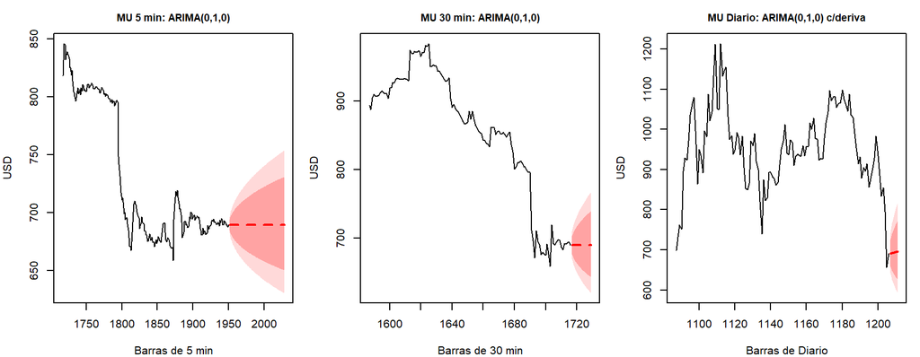

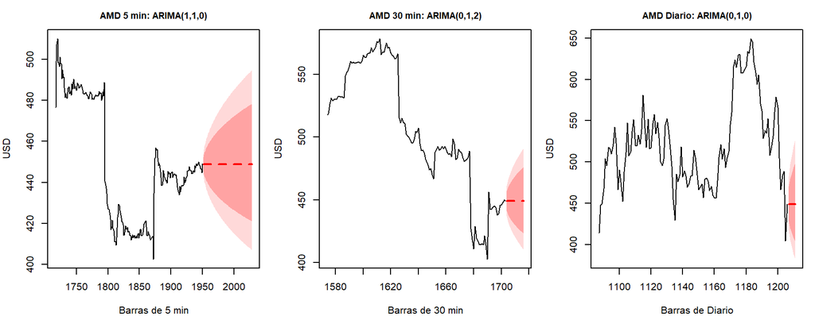

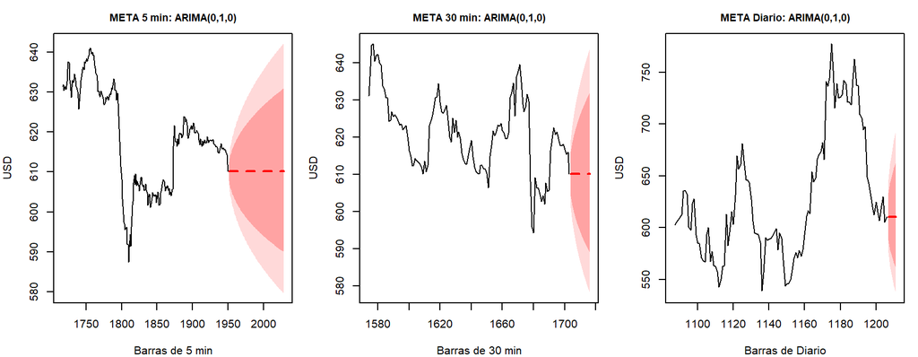

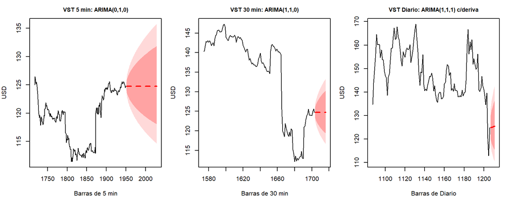

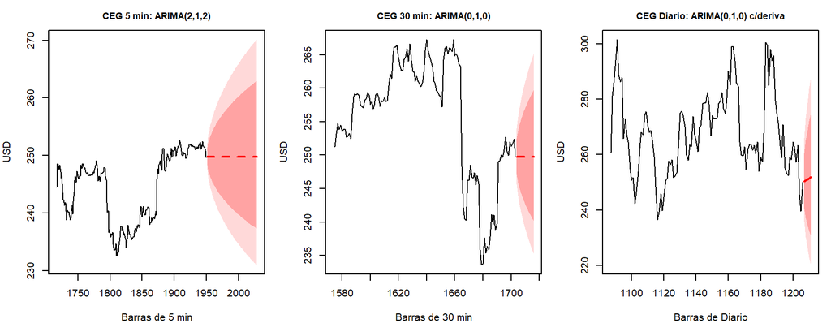

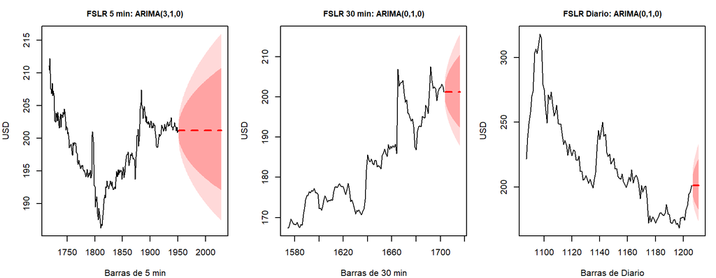

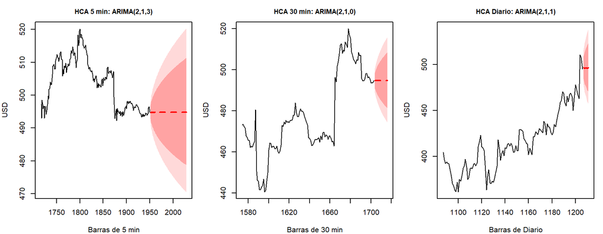

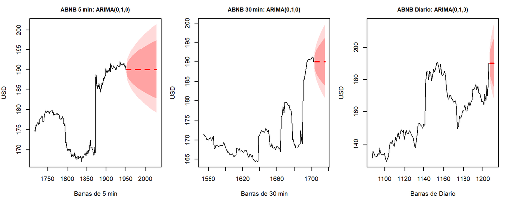

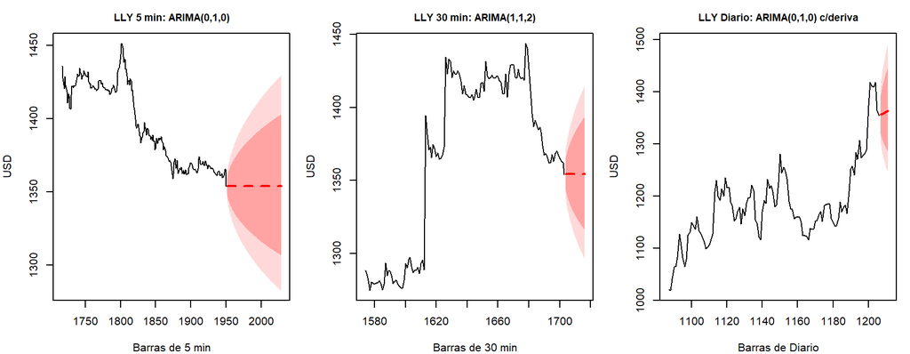

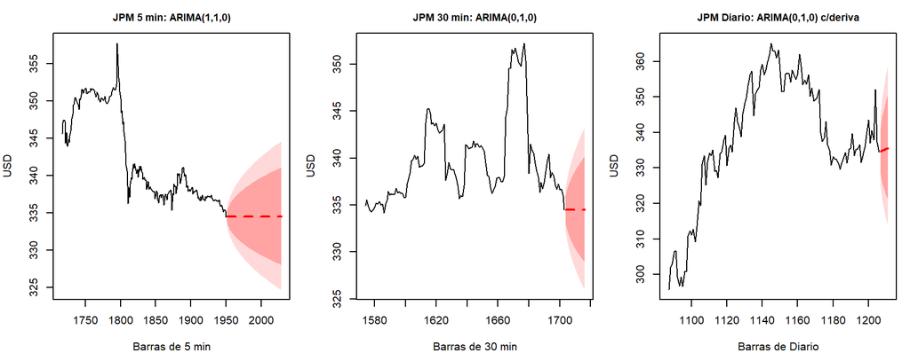

```r
graficar_pronostico <- function(frec, tk, ultimos) {
  s  <- serie_log(frec, tk)
  m  <- ajustar_arima(s$y, deriva = frec == "Diario")
  fc <- forecast(m, h = HFC[[frec]], level = c(80, 95))
  n  <- length(s$y)
  x_hist <- (n - ultimos + 1):n
  x_fc   <- n + seq_len(HFC[[frec]])
  plot(x_hist, exp(s$y[x_hist]), type = "l", xlim = c(min(x_hist), max(x_fc)),
       ylim = range(exp(c(s$y[x_hist], fc$lower[, 2], fc$upper[, 2]))),
       xlab = paste("Barras de", frec), ylab = "USD", cex.main = 0.9,
       main = sprintf("%s %s: %s", tk, frec, etiqueta_arima(m)))
  polygon(c(x_fc, rev(x_fc)), exp(c(fc$lower[, 2], rev(fc$upper[, 2]))),
          col = adjustcolor("red", 0.15), border = NA)
  polygon(c(x_fc, rev(x_fc)), exp(c(fc$lower[, 1], rev(fc$upper[, 1]))),
          col = adjustcolor("red", 0.25), border = NA)
  lines(x_fc, exp(fc$mean), col = "red", lwd = 2, lty = 2)
}

# Una fila por acción: 5 min (últimas 3 sesiones), 30 min (últimas 10) y diario (últimos 120 días)
for (tk in ACCIONES) {
  par(mfrow = c(1, 3), mar = c(4, 4, 2.5, 1))
  graficar_pronostico("5 min",  tk, 78 * 3)
  graficar_pronostico("30 min", tk, 13 * 10)
  graficar_pronostico("Diario", tk, 120)
}
```

```r
par(mfrow = c(1, 1))
```

# 9 Volatilidad: ARCH y GARCH

$$r_t = \mu + u_t,\quad u_t = \sigma_t
z_t,\qquad \sigma_t^2 = \omega + \alpha u_{t-1}^2 + \beta \sigma_{t-1}^2
\;\;(+\;\gamma\, u_{t-1}^2 I_{u_{t-1}<0}\ \text{en GJR})$$

Se estima GARCH(1,1) y GJR-GARCH(1,1) con distribución **t** para cada acción con rendimientos **diarios** (desde 2022) y de **30 min** (excluyendo el salto nocturno). A 5 min no se estima, porque la forma de “J” invertida de la volatilidad intradía domina la dinámica y requeriría un modelo estacional.

```r
spec_garch <- ugarchspec(
  variance.model     = list(model = "sGARCH", garchOrder = c(1, 1)),
  mean.model         = list(armaOrder = c(0, 0), include.mean = TRUE),
  distribution.model = "std")
spec_gjr <- ugarchspec(
  variance.model     = list(model = "gjrGARCH", garchOrder = c(1, 1)),
  mean.model         = list(armaOrder = c(0, 0), include.mean = TRUE),
  distribution.model = "std")

ajustar_garch <- function(r, spec) {
  fit <- tryCatch(ugarchfit(spec, data = r, solver = "hybrid"), error = function(e) NULL)
  if (is.null(fit) || convergence(fit) != 0) return(NULL)
  fit
}

garch_eval <- function(r, tk, frec) {
  r <- as.numeric(na.omit(r))
  arch_p <- ArchTest(r - mean(r), lags = 10)$p.value
  g  <- ajustar_garch(r, spec_garch)
  gj <- ajustar_garch(r, spec_gjr)
  if (is.null(g)) return(list(tabla = tibble(frecuencia = frec, ticker = tk, ARCH_LM_p = arch_p),
                              fit = NULL))
  cf <- coef(g)
  vol1 <- as.numeric(sigma(ugarchforecast(g, n.ahead = 1)))
  list(fit = g,
       tabla = tibble(frecuencia = frec, ticker = tk, ARCH_LM_p = arch_p,
                      alpha = cf[["alpha1"]], beta = cf[["beta1"]],
                      persistencia = cf[["alpha1"]] + cf[["beta1"]],
                      nu_t = cf[["shape"]],
                      gamma_GJR = if (is.null(gj)) NA_real_ else coef(gj)[["gamma1"]],
                      AIC_GARCH = infocriteria(g)["Akaike", ],
                      AIC_GJR   = if (is.null(gj)) NA_real_ else infocriteria(gj)["Akaike", ],
                      vol_siguiente = vol1,
                      vol_media_muestra = sd(r)))
}
```

```r
garch_d  <- map(ACCIONES, ~ garch_eval(RD[, .x],  .x, "Diario")) |> set_names(ACCIONES)
garch_30 <- map(ACCIONES, ~ garch_eval(R30[, .x], .x, "30 min")) |> set_names(ACCIONES)

garch_tab <- bind_rows(map_dfr(garch_d, "tabla"), map_dfr(garch_30, "tabla")) |>
  mutate(mejor = if_else(AIC_GJR < AIC_GARCH, "GJR", "GARCH"),
         vida_media = log(0.5) / log(persistencia))
knitr::kable(garch_tab, digits = 3,
             caption = "GARCH(1,1)-t y GJR-GARCH: parámetros y volatilidad pronosticada (% por periodo)")
```

GARCH(1,1)-t y GJR-GARCH: parámetros y volatilidad pronosticada (% por periodo)

| frecuencia | ticker | ARCH_LM_p | alpha | beta | persistencia | nu_t | gamma_GJR | AIC_GARCH | AIC_GJR | vol_siguiente | vol_media_muestra | mejor | vida_media |
| --- | --- | --- | --- | --- | --- | --- | --- | --- | --- | --- | --- | --- | --- |
| Diario | MU | 0.000 | 0.050 | 0.945 | 0.995 | 6.673 | 0.011 | 5.236 | 5.237 | 5.922 | 3.676 | GARCH | 136.955 |
| Diario | AMD | 0.001 | 0.017 | 0.982 | 0.999 | 4.687 | 0.005 | 5.305 | 5.306 | 5.090 | 3.676 | GARCH | 506.769 |
| Diario | META | 0.965 | 0.025 | 0.957 | 0.982 | 3.431 | 0.026 | 4.560 | 4.553 | 2.676 | 2.916 | GJR | 37.458 |
| Diario | VST | 0.002 | 0.068 | 0.929 | 0.997 | 4.813 | -0.031 | 4.832 | 4.833 | 5.810 | 3.204 | GARCH | 232.613 |
| Diario | CEG | 0.000 | 0.026 | 0.971 | 0.997 | 3.861 | 0.017 | 4.795 | 4.795 | 3.236 | 3.072 | GARCH | 205.213 |
| Diario | FSLR | 0.633 | 0.000 | 0.990 | 0.990 | 4.099 | 0.008 | 5.161 | 5.161 | 3.402 | 3.439 | GJR | 66.501 |
| Diario | HCA | 0.999 | 0.017 | 0.972 | 0.988 | 4.062 | 0.017 | 3.911 | 3.911 | 2.204 | 1.959 | GJR | 58.872 |
| Diario | ABNB | 0.000 | 0.040 | 0.954 | 0.993 | 4.415 | 0.027 | 4.637 | 4.638 | 3.357 | 2.762 | GARCH | 105.751 |
| Diario | LLY | 0.000 | 0.005 | 0.994 | 0.999 | 3.794 | 0.011 | 4.099 | 4.098 | 2.247 | 2.068 | GJR | 692.597 |
| Diario | JPM | 0.000 | 0.125 | 0.766 | 0.891 | 4.410 | 0.162 | 3.511 | 3.503 | 2.154 | 1.535 | GJR | 5.985 |
| 30 min | MU | 0.000 | 0.092 | 0.907 | 0.999 | 4.087 | 0.027 | 2.389 | 2.390 | 1.462 | 0.920 | GARCH | 692.786 |
| 30 min | AMD | 0.000 | 0.058 | 0.940 | 0.999 | 3.746 | 0.042 | 2.067 | 2.066 | 1.274 | 0.760 | GJR | 617.371 |
| 30 min | META | 0.012 | 0.296 | 0.311 | 0.608 | 3.737 | -0.037 | 1.025 | 1.026 | 0.627 | 0.450 | GARCH | 1.392 |
| 30 min | VST | 0.000 | 0.264 | 0.420 | 0.683 | 4.475 | -0.006 | 1.528 | 1.530 | 0.611 | 0.568 | GARCH | 1.820 |
| 30 min | CEG | 0.000 | 0.235 | 0.411 | 0.646 | 5.428 | 0.070 | 1.420 | 1.420 | 0.667 | 0.528 | GARCH | 1.587 |
| 30 min | FSLR | 0.475 | 0.024 | 0.966 | 0.991 | 4.778 | 0.005 | 1.972 | 1.973 | 0.924 | 0.695 | GARCH | 75.495 |
| 30 min | HCA | 0.919 | 0.189 | 0.385 | 0.574 | 4.239 | 0.054 | 0.871 | 0.872 | 0.360 | 0.423 | GARCH | 1.249 |
| 30 min | ABNB | 0.043 | 0.045 | 0.921 | 0.966 | 4.333 | 0.047 | 0.856 | 0.854 | 0.521 | 0.398 | GJR | 19.994 |
| 30 min | LLY | 0.295 | 0.191 | 0.243 | 0.434 | 4.164 | 0.006 | 0.812 | 0.814 | 0.438 | 0.391 | GARCH | 0.831 |
| 30 min | JPM | 0.000 | 0.296 | 0.266 | 0.562 | 4.292 | 0.034 | 0.067 | 0.068 | 0.334 | 0.277 | GARCH | 1.202 |

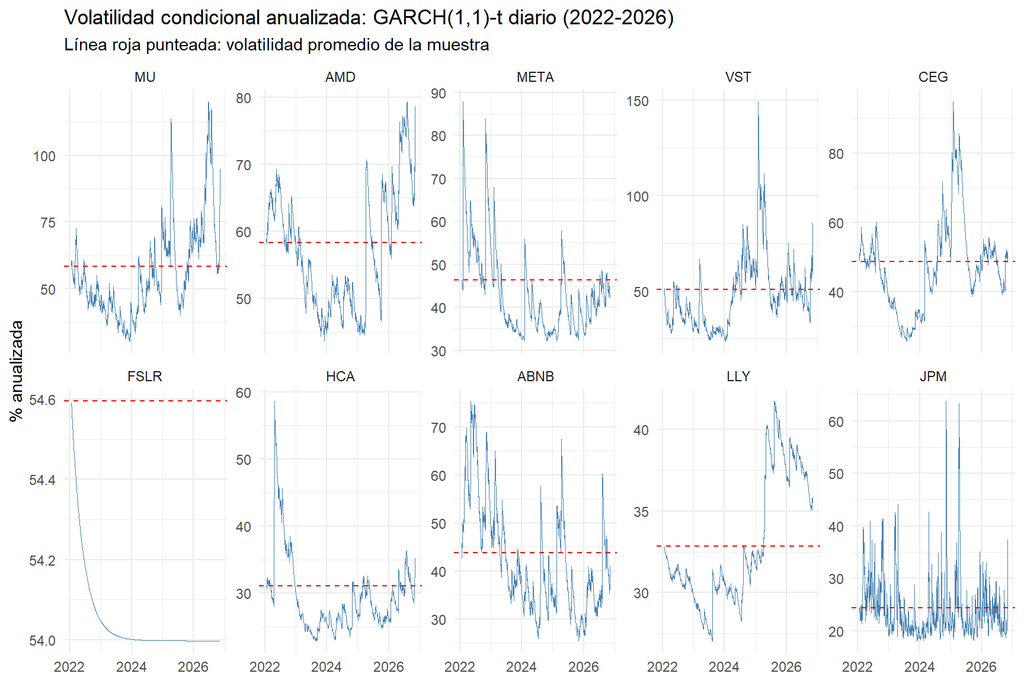

```r
fechas_rd <- as.Date(index(RD))

# Volatilidad condicional anualizada de cada acción (omite las que no convergieron)
vol_df <- imap_dfr(garch_d, function(x, tk) {
  if (is.null(x$fit)) return(NULL)
  tibble(ticker = tk, fecha = fechas_rd,
         vol_anual = as.numeric(sigma(x$fit)) * sqrt(252))
}) |>
  mutate(ticker = factor(ticker, levels = ACCIONES))

# Volatilidad promedio de la muestra (referencia)
vol_media <- tibble(ticker = factor(ACCIONES, levels = ACCIONES),
                    vol_hist = sapply(ACCIONES, function(tk) sd(RD[, tk]) * sqrt(252)))

ggplot(vol_df, aes(fecha, vol_anual)) +
  geom_line(linewidth = 0.3, colour = "steelblue") +
  geom_hline(data = vol_media, aes(yintercept = vol_hist),
             colour = "red", linetype = "dashed") +
  facet_wrap(~ ticker, ncol = 5, scales = "free_y") +
  labs(title = "Volatilidad condicional anualizada: GARCH(1,1)-t diario (2022-2026)",
       subtitle = "Línea roja punteada: volatilidad promedio de la muestra",
       x = NULL, y = "% anualizada") +
  theme_minimal()
```

# 10 Estrategia de portafolio para HowMarketsWorks

1. **Riesgo:** volatilidad de la sesión del lunes pronosticada con GARCH(1,1)-t sobre rendimientos de apertura a cierre, y correlación de los residuos estandarizados (modelo CCC).
2. **Rendimiento esperado:** promedio de apertura a cierre de los últimos 252 días.
3. **Tres portafolios:** pesos iguales (1/N), **mínima varianza** y **máximo Sharpe**, con un tope de 25% por acción y solo posiciones largas.
4. **VaR 95% de la sesión** (en % y en USD) y **número de acciones** a comprar con USD 894,529.21.

```r
# Rendimiento de la sesión: de la apertura al cierre del mismo día (sin el salto nocturno)
ROC <- pd_ |>
  filter(ticker %in% ACCIONES, fecha >= INICIO_D) |>
  mutate(ret_oc = 100 * log(close / open)) |>
  select(fecha, ticker, ret_oc) |>
  pivot_wider(names_from = ticker, values_from = ret_oc) |>
  arrange(fecha)
ROC <- na.omit(xts(select(ROC, all_of(ACCIONES)), order.by = ROC$fecha))

# GARCH(1,1)-t sobre los rendimientos de apertura a cierre: pronóstico de la volatilidad del lunes
garch_oc <- map(ACCIONES, ~ garch_eval(ROC[, .x], .x, "Apertura-cierre")) |> set_names(ACCIONES)
knitr::kable(map_dfr(garch_oc, "tabla"), digits = 3,
             caption = "GARCH sobre rendimientos de apertura a cierre (% por sesión)")
```

GARCH sobre rendimientos de apertura a cierre (% por sesión)

| frecuencia | ticker | ARCH_LM_p | alpha | beta | persistencia | nu_t | gamma_GJR | AIC_GARCH | AIC_GJR | vol_siguiente | vol_media_muestra |
| --- | --- | --- | --- | --- | --- | --- | --- | --- | --- | --- | --- |
| Apertura-cierre | MU | 0.000 | 0.066 | 0.921 | 0.987 | 6.041 | 0.037 | 4.671 | 4.671 | 4.498 | 2.735 |
| Apertura-cierre | AMD | 0.019 | 0.008 | 0.990 | 0.998 | 5.531 | 0.012 | 4.849 | 4.848 | 3.060 | 2.851 |
| Apertura-cierre | META | 0.000 | 0.052 | 0.923 | 0.976 | 7.361 | 0.040 | 4.085 | 4.084 | 2.089 | 1.978 |
| Apertura-cierre | VST | 0.000 | 0.062 | 0.935 | 0.997 | 5.678 | -0.017 | 4.606 | 4.607 | 3.380 | 2.690 |
| Apertura-cierre | CEG | 0.000 | 0.031 | 0.967 | 0.998 | 5.791 | 0.003 | 4.565 | 4.567 | 2.344 | 2.575 |
| Apertura-cierre | FSLR | 0.048 | 0.073 | 0.567 | 0.640 | 6.193 | -0.002 | 4.870 | 4.871 | 2.935 | 2.836 |
| Apertura-cierre | HCA | 0.397 | 0.037 | 0.940 | 0.977 | 4.777 | 0.023 | 3.662 | 3.662 | 1.936 | 1.616 |
| Apertura-cierre | ABNB | 0.000 | 0.045 | 0.947 | 0.992 | 6.417 | 0.047 | 4.262 | 4.256 | 1.990 | 2.265 |
| Apertura-cierre | LLY | 0.159 | 0.009 | 0.989 | 0.998 | 6.835 | 0.001 | 3.754 | 3.756 | 1.699 | 1.620 |
| Apertura-cierre | JPM | 0.000 | 0.131 | 0.540 | 0.671 | 4.657 | 0.035 | 3.214 | 3.210 | 2.028 | 1.291 |

```r
vol_g <- sapply(ACCIONES, function(tk) {
  x <- garch_oc[[tk]]$tabla$vol_siguiente
  if (is.null(x) || is.na(x)) sd(ROC[, tk]) else x
})
z <- sapply(ACCIONES, function(tk) {
  f <- garch_oc[[tk]]$fit
  if (is.null(f)) as.numeric(scale(ROC[, tk])) else as.numeric(residuals(f, standardize = TRUE))
})
corr  <- cor(z, use = "pairwise.complete.obs")
Sigma <- diag(vol_g) %*% corr %*% diag(vol_g)
Sigma <- (Sigma + t(Sigma)) / 2
dimnames(Sigma) <- list(ACCIONES, ACCIONES)

mu <- colMeans(tail(ROC, 252))     # rendimiento promedio por sesión (%) del último año
beta_d <- with(filter(betas, frecuencia == "Diario"), setNames(beta, as.character(ticker)))
rf <- RF_ANUAL / 252

knitr::kable(tibble(ticker = ACCIONES, rend_prom_sesion = mu, vol_lunes_GARCH = vol_g),
             digits = 3, caption = "Insumos del portafolio (% por sesión)")
```

Insumos del portafolio (% por sesión)

| ticker | rend_prom_sesion | vol_lunes_GARCH |
| --- | --- | --- |
| MU | 0.037 | 4.498 |
| AMD | 0.098 | 3.060 |
| META | -0.067 | 2.089 |
| VST | -0.338 | 3.380 |
| CEG | -0.279 | 2.344 |
| FSLR | -0.160 | 2.935 |
| HCA | 0.069 | 1.936 |
| ABNB | 0.040 | 1.990 |
| LLY | -0.051 | 1.699 |
| JPM | -0.063 | 2.028 |

```r
round(corr, 2)
```

```
##        MU  AMD META  VST  CEG FSLR  HCA ABNB  LLY  JPM
## MU   1.00 0.59 0.39 0.32 0.31 0.27 0.18 0.30 0.18 0.24
## AMD  0.59 1.00 0.49 0.36 0.33 0.28 0.11 0.37 0.19 0.28
## META 0.39 0.49 1.00 0.24 0.31 0.22 0.19 0.44 0.24 0.29
## VST  0.32 0.36 0.24 1.00 0.59 0.24 0.14 0.17 0.12 0.23
## CEG  0.31 0.33 0.31 0.59 1.00 0.24 0.12 0.18 0.16 0.22
## FSLR 0.27 0.28 0.22 0.24 0.24 1.00 0.15 0.17 0.11 0.18
## HCA  0.18 0.11 0.19 0.14 0.12 0.15 1.00 0.18 0.17 0.26
## ABNB 0.30 0.37 0.44 0.17 0.18 0.17 0.18 1.00 0.12 0.30
## LLY  0.18 0.19 0.24 0.12 0.16 0.11 0.17 0.12 1.00 0.18
## JPM  0.24 0.28 0.29 0.23 0.22 0.18 0.26 0.30 0.18 1.00
```

```r
n <- length(ACCIONES)

# Mínima varianza: min w'Σw  s.a.  sum(w) = 1, 0 <= w <= tope
sol_mv <- solve.QP(Dmat = 2 * Sigma, dvec = rep(0, n),
                   Amat = cbind(rep(1, n), diag(n), -diag(n)),
                   bvec = c(1, rep(0, n), rep(-TOPE_PESO, n)), meq = 1)
w_mv <- pmax(sol_mv$solution, 0); w_mv <- w_mv / sum(w_mv)

# Máximo Sharpe (cartera tangente). Cambio de variable y = w / k:
# min y'Σy  s.a.  (mu - rf)'y = 1,  y >= 0,  y_i <= tope * sum(y)
exceso <- mu - rf
w_ms <- tryCatch({
  A <- cbind(exceso, diag(n), TOPE_PESO * matrix(1, n, n) - diag(n))
  s <- solve.QP(Dmat = 2 * Sigma, dvec = rep(0, n), Amat = A,
                bvec = c(1, rep(0, n), rep(0, n)), meq = 1)
  y <- pmax(s$solution, 0); y / sum(y)
}, error = function(e) {
  message("Ninguna acción tiene rendimiento esperado > rf: se usa mínima varianza")
  w_mv
})

pesos <- data.frame("Igual (1/N)" = rep(1 / n, n), "Min. varianza" = w_mv,
                    "Max. Sharpe" = w_ms, row.names = ACCIONES, check.names = FALSE)

metricas <- sapply(pesos, function(w) {
  sig <- sqrt(as.numeric(t(w) %*% Sigma %*% w))
  rp  <- as.numeric(tail(ROC, 252) %*% w)
  c("Rend. esperado por sesión (%)" = sum(w * mu),
    "Vol. pronosticada sesión (%)"  = sig,
    "Sharpe anualizado"             = (sum(w * mu) - rf) / sig * sqrt(252),
    "VaR 95% sesión param. (%)"     = 1.645 * sig,
    "VaR 95% sesión histórico (%)"  = -quantile(rp, 0.05, names = FALSE),
    "VaR 95% sesión (USD)"          = 1.645 * sig / 100 * CAPITAL * (1 - COLCHON),
    "Beta del portafolio"           = sum(w * beta_d[ACCIONES]))
})

knitr::kable(round(pesos, 3), caption = "Pesos por estrategia")
```

Pesos por estrategia

|  | Igual (1/N) | Min. varianza | Max. Sharpe |
| --- | --- | --- | --- |
| MU | 0.1 | 0.000 | 0.25 |
| AMD | 0.1 | 0.000 | 0.25 |
| META | 0.1 | 0.059 | 0.00 |
| VST | 0.1 | 0.000 | 0.00 |
| CEG | 0.1 | 0.114 | 0.00 |
| FSLR | 0.1 | 0.055 | 0.00 |
| HCA | 0.1 | 0.218 | 0.25 |
| ABNB | 0.1 | 0.175 | 0.25 |
| LLY | 0.1 | 0.250 | 0.00 |
| JPM | 0.1 | 0.128 | 0.00 |

```r
knitr::kable(round(metricas, 2), caption = "Riesgo y rendimiento esperado")
```

Riesgo y rendimiento esperado

|  | Igual (1/N) | Min. varianza | Max. Sharpe |
| --- | --- | --- | --- |
| Rend. esperado por sesión (%) | -0.07 | -0.04 | 0.06 |
| Vol. pronosticada sesión (%) | 1.54 | 1.14 | 2.08 |
| Sharpe anualizado | -0.90 | -0.82 | 0.34 |
| VaR 95% sesión param. (%) | 2.54 | 1.88 | 3.42 |
| VaR 95% sesión histórico (%) | 2.05 | 1.48 | 2.78 |
| VaR 95% sesión (USD) | 22241.74 | 16499.05 | 30017.32 |
| Beta del portafolio | 1.28 | 0.94 | 1.56 |